# Environmental parameters - analysis & variable selection

2022-11-15

Setup!

Define the working subdirectories.

````r
```r
```r
## print the working directory, just to be on the safe side
paste(\You are here: \, getwd())
````

```
[1] \You are here:  /media/eti/My Passport/rabota/documents/phd/thesis/4-results-discussion/data-n-analyses/results-analysis\
```

````r
```r
```r
data.dir <- \data\    # input data files
functions.dir <- \R\  # functions & scripts
save.dir <- \output\  # clean data, output from models & more complex calculations
figures.dir <- \figs\ # plots & figures
````

Import libraries.

````r
```r
library(here) # painless relative paths to subdurectories, etc.
````

```r
library(tidyverse) # data manipulation, cleaning, aggregation
```

```r
library(viridis)
```

This notebook details the analyses & variable selection of the environmental parameters. I’m giving them their own notebook for clarity and simplicity.  
This is a direct continuation of the cleanup & summarization notebook on environmental parameters; I’m going to import some of the summary tibbles produced there directly from the save folder.  
Again, the analyses will proceed in 3 separate datasets: 2012, sand (2013-2014), and seagrass (2013-2014).  
Two lines of analysis will be applied:  
1) PCA - to see which variables best account for the differences between stations. The “winners” will go on to the multivariate analyses attempting to relate community structure to environment.  
PCA will be applied on 3 sets of explanatory variables - water column (+ LUSI), sediments (+ seagrass, where relevant), and heavy metals; y = station (and habitat, in the case of sand). Prior to the PCA, some (feeble) variable selection will be performed - mostly to get rid of highly correlated variables.  
2) Elastic net - another method of variable selection.  
Again, there will be 3 sets of explanatory variables - as above.  
y = categorical (station, habitats) - logistic regression with multinomial models & grouped lasso penalty.  
y = numeric (species abundances) - multi-response Gaussian linear regression with many correlated responses (+ maybe should be applied over a sparse matrix).

##### Sand stations (Burgas Bay, 2013-2014)

Import environmental data.

````r
```r
```r
## contains the long-term water column parameters, summarized by station.
water <- read_csv(here(save.dir, \water_column_summary_LT.csv\))
```r
```r
## filter (manually) to get only the sand 2013-2014 stations
(water.sand <- water %>%
    filter(station %in% c(\Kraimorie\, \Chukalya\, \Akin\, \Sozopol\, \Agalina\, \Paraskeva\)) %>%
    ## convert station to factor & order
    mutate(station = factor(station, levels = c(\Kraimorie\, \Chukalya\, \Akin\, \Sozopol\, \Agalina\, \Paraskeva\))) %>%
    arrange(station)
)
````

| station | Ntotal_mean | Ninorg_mean | NH4_mean | NO3_mean | PO4_mean | chl_a_mean | seston_mean | secchi_mean | O2 | O2_bottom | temperature | temperature_bottom |
| --- | --- | --- | --- | --- | --- | --- | --- | --- | --- | --- | --- | --- |
| Kraimorie | 19.61 | 4.30 | 1.09 | 2.63 | 0.34 | 3.22 | 2.29 | 3.27 | 7.965667 | 5.9025 | 24.34278 | 22.72500 |
| Chukalya | 19.21 | 4.01 | 0.96 | 2.35 | 0.32 | 3.09 | 2.42 | 4.39 | 7.629519 | 5.2025 | 23.23132 | 21.12500 |
| Akin | 17.19 | 3.53 | 0.84 | 2.07 | 0.27 | 3.06 | 2.17 | 5.19 | 8.324065 | 7.5100 | 23.66838 | 21.20000 |
| Sozopol | 17.56 | 3.42 | 0.66 | 2.57 | 0.17 | 2.72 | 1.48 | 6.35 | 8.323346 | 7.9925 | 23.98680 | 23.27500 |
| Agalina | 17.52 | 3.43 | 0.72 | 2.53 | 0.15 | 2.52 | 1.28 | 6.99 | 8.074048 | 6.9800 | 23.17619 | 21.93333 |
| Paraskeva | 15.66 | 3.20 | 0.65 | 2.17 | 0.12 | 2.24 | 1.19 | 7.35 | 7.930909 | 7.4750 | 23.86364 | 23.65000 |

Import the sediment data (it also contains the heavy metals).

````r
```r
```r
sediments <- read_csv(here(save.dir, \sediments_imputed_sand.csv\))
```r
```r
## split into sediment parameters sesnu stricto, and heavy metals
(sediments.sand <- sediments %>%
    select(station:year, TOM:silt_clay) %>%
    ## make station a factor
    mutate(station = factor(station, levels = c(\Kraimorie\, \Chukalya\, \Akin\, \Sozopol\, \Agalina\, \Paraskeva\))) %>%
    arrange(station)
)
````

```r
(heavy.metals.sand <- sediments %>%
    select(station:year, Cu:Ni) %>%
    ## make station a factor
    mutate(station = factor(station, levels = c(\Kraimorie\, \Chukalya\, \Akin\, \Sozopol\, \Agalina\, \Paraskeva\))) %>%
    arrange(station)
)
```

| station | month | year | Cu | Pb | Zn | Cd | Mn | Fe | Ni |
| --- | --- | --- | --- | --- | --- | --- | --- | --- | --- |
| Kraimorie | 6 | 2013 | 38.390 | 33.801 | 45.599 | 3.475 | 350.843 | 13892.415 | 27.528 |
| Kraimorie | 9 | 2013 | 38.390 | 33.801 | 45.599 | 3.475 | 350.843 | 13892.415 | 27.528 |
| Kraimorie | 7 | 2014 | 38.390 | 33.801 | 45.599 | 3.475 | 350.843 | 13892.415 | 27.528 |
| Chukalya | 6 | 2013 | 8.514 | 24.163 | 12.746 | 1.476 | 310.089 | 6258.415 | 5.364 |
| Chukalya | 9 | 2013 | 8.514 | 24.163 | 12.746 | 1.476 | 310.089 | 6258.415 | 5.364 |
| Chukalya | 7 | 2014 | 8.514 | 24.163 | 12.746 | 1.476 | 310.089 | 6258.415 | 5.364 |
| Akin | 6 | 2013 | 15.060 | 31.113 | 22.366 | 1.491 | 359.294 | 13050.248 | 4.871 |
| Akin | 9 | 2013 | 15.060 | 31.113 | 22.366 | 1.491 | 359.294 | 13050.248 | 4.871 |
| Akin | 7 | 2014 | 15.060 | 31.113 | 22.366 | 1.491 | 359.294 | 13050.248 | 4.871 |
| Sozopol | 6 | 2013 | 2.842 | 12.314 | 23.004 | 4.736 | 129.296 | 3190.189 | 1.691 |

[output cut: 8 more lines]

Import LUSI and add it to the water column data, although strictly speaking, it isn’t really..

````r
```r
```r
(lusi <- read_csv(here(save.dir, \lusi_st.csv\))
)
```r
```r
## we'll match them by station - and we only want the sand stations - the rows of x (the water column data) where there are matching values in y (LUSI) -> e.g. inner join
(water.sand <- inner_join(water.sand,
                          lusi %>% select(-watershed),
                          by = \station\) %>%
    ## turn station back into a factor (gets coerced to character)
    mutate(station = factor(station, levels = c(\Kraimorie\, \Chukalya\, \Akin\, \Sozopol\, \Agalina\, \Paraskeva\))) %>%
    arrange(station)
)
````

```
Column `station` joining factor and character vector, coercing into character vector
```

| station | Ntotal_mean | Ninorg_mean | NH4_mean | NO3_mean | PO4_mean | chl_a_mean | seston_mean | secchi_mean | O2 | O2_bottom | temperature | temperature_bottom | LUSI |
| --- | --- | --- | --- | --- | --- | --- | --- | --- | --- | --- | --- | --- | --- |
| Kraimorie | 19.61 | 4.30 | 1.09 | 2.63 | 0.34 | 3.22 | 2.29 | 3.27 | 7.965667 | 5.9025 | 24.34278 | 22.72500 | 6.25 |
| Chukalya | 19.21 | 4.01 | 0.96 | 2.35 | 0.32 | 3.09 | 2.42 | 4.39 | 7.629519 | 5.2025 | 23.23132 | 21.12500 | 4.00 |
| Akin | 17.19 | 3.53 | 0.84 | 2.07 | 0.27 | 3.06 | 2.17 | 5.19 | 8.324065 | 7.5100 | 23.66838 | 21.20000 | 4.00 |
| Sozopol | 17.56 | 3.42 | 0.66 | 2.57 | 0.17 | 2.72 | 1.48 | 6.35 | 8.323346 | 7.9925 | 23.98680 | 23.27500 | 2.00 |
| Agalina | 17.52 | 3.43 | 0.72 | 2.53 | 0.15 | 2.52 | 1.28 | 6.99 | 8.074048 | 6.9800 | 23.17619 | 21.93333 | 2.00 |
| Paraskeva | 15.66 | 3.20 | 0.65 | 2.17 | 0.12 | 2.24 | 1.19 | 7.35 | 7.930909 | 7.4750 | 23.86364 | 23.65000 | 0.75 |

The nutrients all decrease towards the outer bay, more or less so, and so do the chl-a and suspended matter; the transparency (Secchi depth) increases - this is the long-term (anthropgenic) eutrophication gradient in Burgas Bay, consistent with previous studies (..) & models.

Now let’s check the correlations between water column parameters. More or less important: LUSI is (significantly) positively correlated with most long-term nutrient concentrations, chl-a and suspended matter, and negatively correlated with Secchi depth, which is good - shows that it’s a good indicator of the anthropogenic pressure gradient of Burgas Bay. Could maybe be used as a proxy for all of these in the analyses? As a side note, the fact that it doesn’t require the analyses of samples upon water samples is also not too shabby.

````r
```r
```r
Hmisc::rcorr(as.matrix(water.sand %>% select(-station)),
             type = \pearson\)
````

```
                   Ntotal_mean Ninorg_mean NH4_mean NO3_mean PO4_mean
Ntotal_mean               1.00        0.95     0.86     0.58     0.85
Ninorg_mean               0.95        1.00     0.97     0.43     0.92
NH4_mean                  0.86        0.97     1.00     0.23     0.96
NO3_mean                  0.58        0.43     0.23     1.00     0.11
PO4_mean                  0.85        0.92     0.96     0.11     1.00
chl_a_mean                0.84        0.85     0.87     0.17     0.96
seston_mean               0.78        0.84     0.89    -0.03     0.98
secchi_mean              -0.87       -0.96    -0.97    -0.24    -0.98
O2                       -0.38       -0.46    -0.44    -0.04    -0.34
O2_bottom                -0.79       -0.83    -0.81    -0.23    -0.74
temperature               0.08        0.24     0.21     0.24     0.16
temperature_bottom       -0.42       -0.34    -0.44     0.27    -0.56
LUSI                      0.85        0.93     0.96     0.27     0.95
                   chl_a_mean seston_mean secchi_mean    O2 O2_bottom
Ntotal_mean              0.84        0.78       -0.87 -0.38     -0.79
Ninorg_mean              0.85        0.84       -0.96 -0.46     -0.83
NH4_mean                 0.87        0.89       -0.97 -0.44     -0.81
NO3_mean                 0.17       -0.03       -0.24 -0.04     -0.23
PO4_mean                 0.96        0.98       -0.98 -0.34     -0.74
chl_a_mean               1.00        0.95       -0.95 -0.09     -0.58
seston_mean              0.95        1.00       -0.93 -0.31     -0.70
secchi_mean             -0.95       -0.93        1.00  0.30      0.71
O2                      -0.09       -0.31        0.30  1.00      0.84
O2_bottom               -0.58       -0.70        0.71  0.84      1.00
temperature              0.18        0.08       -0.32  0.30      0.21
temperature_bottom      -0.58       -0.64        0.41  0.18      0.48
LUSI                     0.94        0.88       -0.97 -0.17     -0.64
                   temperature temperature_bottom  LUSI
Ntotal_mean               0.08              -0.42  0.85
Ninorg_mean               0.24              -0.34  0.93
NH4_mean                  0.21              -0.44  0.96
NO3_mean                  0.24               0.27  0.27
PO4_mean                  0.16              -0.56  0.95
chl_a_mean                0.18              -0.58  0.94
seston_mean               0.08              -0.64  0.88
secchi_mean              -0.32               0.41 -0.97
O2                        0.30               0.18 -0.17
O2_bottom                 0.21               0.48 -0.64
temperature               1.00               0.65  0.33
```

[output cut: 34 more lines]

```
LUSI               0.0056     0.0191      0.0010      0.7481 0.1741
                   temperature temperature_bottom LUSI
Ntotal_mean        0.8846      0.4044             0.0332
Ninorg_mean        0.6426      0.5037             0.0077
NH4_mean           0.6825      0.3766             0.0024
NO3_mean           0.6419      0.6057             0.6118
PO4_mean           0.7601      0.2458             0.0039
chl_a_mean         0.7284      0.2261             0.0056
seston_mean        0.8873      0.1707             0.0191
secchi_mean        0.5373      0.4198             0.0010
O2                 0.5574      0.7313             0.7481
O2_bottom          0.6918      0.3408             0.1741
temperature                    0.1664             0.5295
temperature_bottom 0.1664                         0.3903
LUSI               0.5295      0.3903
```

Now we’ll proceed with the variable selection for the PCA. For whatever it’s worth, I don’t think PCA with so few observations can be valid, but hey, all the kids are doing it.  
We’ll just eliminate the most inter-correlated variables using package caret.

````r
```r
```r
# calculate the correlation matrix (on the numeric variables only)
water.sand.cors <- cor(water.sand %>% select(-station))

# find and eliminate the highly correlated variables. NB names = FALSE, to return column index
highly.cor.water.sand <- findCorrelation(water.sand.cors, cutoff = 0.85)
water.sand.red <- water.sand %>%
  select(-station) %>% # otherwise column indices don't match
  select(-highly.cor.water.sand)
water.sand.pca <- prcomp(water.sand.red, center = TRUE, scale. = TRUE)
# check the results
summary(water.sand.pca)
````

```
Importance of components:
                         PC1    PC2    PC3    PC4
Standard deviation     1.806 1.3581 1.0845 0.8371
Proportion of Variance 0.466 0.2635 0.1680 0.1001
Cumulative Proportion  0.466 0.7295 0.8975 0.9976
                          PC5       PC6
Standard deviation     0.1295 1.005e-15
Proportion of Variance 0.0024 0.000e+00
Cumulative Proportion  1.0000 1.000e+00
```

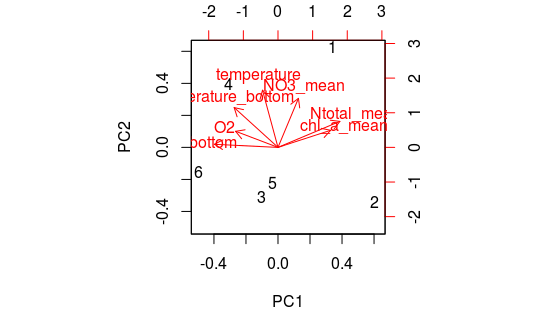

````r
```r
```r
biplot(water.sand.pca)
````

Unfortunately, this eliminates LUSI, which as we saw is highly correlated with all nutrients, etc. - and I’d like to keep it, to check against macrozoobenthic community structure.  
However, for the sake of not throwing away hard work, I will go through the motions of visualizing and exploring the PCA results. Procedure uses packages FactoMineR and factoextra.

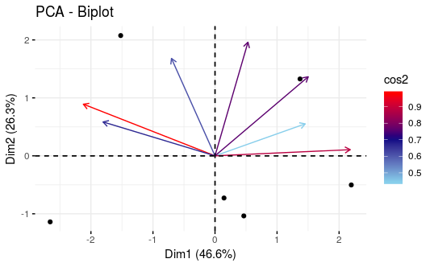

Since I did these, I found out about a new package doing **automatic** exploration & report on the PCA - FactoInvestigate. Let’s try it out, see what we get..  
This inevitably fails, because it can’t describe the dimensions with no actual variation - I’m commenting it out, but leaving it here for the sake of completeness.

````r
```r
```r
# Investigate(water.sand.pca.fin, file = \pca_report_water_sand.Rmd\, document = \html_document\, remove.temp = TRUE)
````

To reiterate - the automatic report **fails** at the attempt to describe the dimensions - that’s because there is nothing to describe; the original data only has 1 value per station - not really appropriate for PCA, which attempts to describe variability after all (what variability with only 1 value?).  
Before that, it manages to say that the analysis should not be attempted at all - see generated report. Quoting: “An estimation of the right number of axes to interpret suggests to not interpret the analysis at all. Indeed, the amount of inertia of the first axis is not higher than that obtained by the 0.95-quantile of random distributions (46.6% against 61.68%). This observation suggests that no axis is carrying a real information.”

**Also, I don’t like how LUSI got excluded - I think in the end, I might just show the correlation table to demonstrate that LUSI reflects well the eutrophication gradient, then just pass it on to the community structure analyses. Will dramatically reduce the number of variables + the uncertainty associated with only a few discrete samples of highly variable parameters such as nutrients and oxygen.**

In any case, let’s save the PCA result - just in case, to avoid repeating a million times later.

````r
```r
```r
write_rds(water.sand.pca.fin, path = here(save.dir, \pca_water_sand_summarized.RDS\))
````

Now do a proper PCA on non-summarized water column data (essentially a repeat of Mitko’s PhD analyses, but ok).

````r
```r
```r
## import water column raw - non-summarized - data.
water.all <- read_csv(here(save.dir, \water_column_raw_clean.csv\))
```r
```r
## get only the sand stations from the water column dataset
(water.sand.all <- water.all %>%
   filter(station %in% c(\Kraimorie\, \Chukalya\, \Akin\, \Sozopol\, \Agalina\, \Paraskeva\)) %>%
   ungroup() %>%
  ## kae station a factor & arrange
   mutate(station = factor(station, levels = c(\Kraimorie\, \Chukalya\, \Akin\, \Sozopol\, \Agalina\, \Paraskeva\))) %>%
    arrange(station)
)
````

| station | year | month | chl_a | Ninorg | NH4 | NO3 | Ntotal | PO4 | seston | secchi |
| --- | --- | --- | --- | --- | --- | --- | --- | --- | --- | --- |
| Kraimorie | 2009 | 7 | 0.7163333 | 1.0686667 | 0.583333333 | 0.4590000 | 3.071333 | 0.14900000 | 1.4800000 | 3.00 |
| Kraimorie | 2009 | 8 | 0.9383333 | 1.3570000 | 0.466666667 | 0.8380000 | 13.045333 | 0.17400000 | 1.5666667 | 1.50 |
| Kraimorie | 2009 | 9 | 4.9393333 | 1.9693333 | 0.866666667 | 1.0406667 | 16.107333 | 0.24400000 | 5.4666667 | 1.50 |
| Kraimorie | 2009 | 10 | 1.1540000 | 1.0350000 | 0.383333333 | 0.6073333 | 15.767667 | 0.17400000 | 0.9866667 | 3.00 |
| Kraimorie | 2009 | 11 | 4.9703333 | 1.4616667 | 0.733333333 | 0.6773333 | 9.701333 | 0.16400000 | 1.3666667 | 2.50 |
| Kraimorie | 2009 | 12 | 1.4280000 | 1.9356667 | 0.916666667 | 0.9026667 | 16.194000 | 0.20400000 | 3.8266667 | 2.50 |
| Kraimorie | 2010 | 1 | 4.3340000 | 14.0666667 | 4.666666667 | 8.6393333 | 40.640333 | 1.48733333 | 5.9940000 | 1.20 |
| Kraimorie | 2010 | 2 | 3.3553333 | 19.2693333 | 3.950000000 | 14.5436667 | 67.140333 | 3.25866667 | 5.6000000 | 0.50 |
| Kraimorie | 2010 | 3 | 7.3680000 | 12.7693333 | 0.816666667 | 2.5583333 | 26.725667 | 0.38333333 | 2.1583333 | 2.00 |
| Kraimorie | 2010 | 4 | 2.8273333 | 8.8760000 | 0.900000000 | 7.6016667 | 17.700000 | 0.14900000 | 0.9366667 | 2.50 |

[output cut: 141 more lines]

Reduce the dataset a little, removing correlations.

````r
```r
```r
# calculate the correlation matrix (on the numeric variables only)
water.sand.all.cors <- cor(water.sand.all %>% select(-c(station:month)))

# find and eliminate the highly correlated variables. NB names = FALSE, to return column index
highly.cor.water.sand.all <- findCorrelation(water.sand.all.cors, cutoff = 0.85)
(water.sand.all.red <- water.sand.all %>%
    select(-c(station:month)) %>% # otherwise column indices don't match
    select(-highly.cor.water.sand.all)
)
````

| chl_a | NH4 | NO3 | Ntotal | PO4 | seston | secchi |
| --- | --- | --- | --- | --- | --- | --- |
| 0.7163333 | 0.583333333 | 0.4590000 | 3.071333 | 0.14900000 | 1.4800000 | 3.00 |
| 0.9383333 | 0.466666667 | 0.8380000 | 13.045333 | 0.17400000 | 1.5666667 | 1.50 |
| 4.9393333 | 0.866666667 | 1.0406667 | 16.107333 | 0.24400000 | 5.4666667 | 1.50 |
| 1.1540000 | 0.383333333 | 0.6073333 | 15.767667 | 0.17400000 | 0.9866667 | 3.00 |
| 4.9703333 | 0.733333333 | 0.6773333 | 9.701333 | 0.16400000 | 1.3666667 | 2.50 |
| 1.4280000 | 0.916666667 | 0.9026667 | 16.194000 | 0.20400000 | 3.8266667 | 2.50 |
| 4.3340000 | 4.666666667 | 8.6393333 | 40.640333 | 1.48733333 | 5.9940000 | 1.20 |
| 3.3553333 | 3.950000000 | 14.5436667 | 67.140333 | 3.25866667 | 5.6000000 | 0.50 |
| 7.3680000 | 0.816666667 | 2.5583333 | 26.725667 | 0.38333333 | 2.1583333 | 2.00 |
| 2.8273333 | 0.900000000 | 7.6016667 | 17.700000 | 0.14900000 | 0.9366667 | 2.50 |

[output cut: 141 more lines]

```
Missing values are imputed by the mean of the variable: you should use the imputePCA function of the missMDA package
```

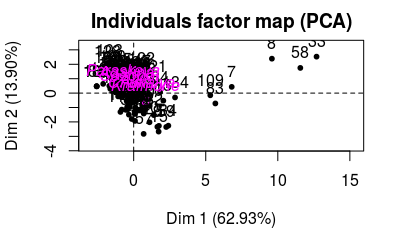

````r
```r
```r
## scale and center the reduced dataset
water.sand.all.red.scaled <- scale(water.sand.all.red,
                                   center = TRUE, scale = TRUE)
water.sand.all.red.scaled <- bind_cols(water.sand.all %>% select(station),
                                       as.tibble(water.sand.all.red.scaled))
## perform the PCA
water.sand.all.red.pca <- PCA(water.sand.all.red.scaled, scale.unit = FALSE, quali.sup = 1)
````

```
-- creation of the .Rmd file (time spent : 0s) --

-- detection of outliers (time spent : 0.01s) --
0 outlier(s) terminated

-- analysis of the inertia (time spent : 0.04s) --
1 component(s) carrying information : total inertia of 62.9%

-- components description (time spent : 3.35s) --
dim. 1
Chi-squared approximation may be incorrect

-- classification (time spent : 3.71s) --
Chi-squared approximation may be incorrect
3 clusters

-- annexes writing (time spent : 3.99s) --

-- saving data (time spent : 4.16s) --

-- outputs compilation (time spent : 4.18s) --
xdg-open: unexpected argument 'Passport/rabota/documents/phd/thesis/4-results-discussion/data-n-analyses/results-analysis/pca_water_sand_all_red_report.html'
Try 'xdg-open --help' for more information.
-- task completed (time spent : 15.56s) --
This interpretation of the results was carried out automatically,
it cannot match the quality of a personal interpretation
```

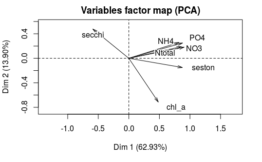

````r
```r
```r
Investigate(water.sand.all.red.pca,
            file = \pca_water_sand_all_red_report.Rmd\, document = \html_document\,
            out.selec = TRUE,
            remove.temp = TRUE)
````

Goody! At least the analysis is significant - although the elimination threshold of correlation is probably too high - judging from how close the vectors of the N species are situated…

````r
```r
```r
write_rds(water.sand.all.red.pca,
          here(save.dir, \pca_water_sand_all_red.RDS\))
````

Now let’s add LUSI and try this once more, with feeling..

````r
```r
```r
water.sand.all.LUSI <- inner_join(water.sand.all,
                                  lusi %>% select(-watershed),
                                  by = \station\) %>%
  ## turn station back into a factor (gets coerced to character)
  mutate(station = factor(station, levels = c(\Kraimorie\, \Chukalya\, \Akin\, \Sozopol\, \Agalina\, \Paraskeva\))) %>%
  arrange(station)
````

```
Column `station` joining factor and character vector, coercing into character vector
```

````r
```r
```r
# calculate the correlation matrix (on the numeric variables only)
water.sand.all.LUSI.cors <- cor(water.sand.all.LUSI %>% select(-c(station:month)))

# find and eliminate the highly correlated variables. NB names = FALSE, to return column index
highly.cor.water.sand.all.LUSI <- findCorrelation(water.sand.all.LUSI.cors, cutoff = 0.85)
(water.sand.all.LUSI.red <- water.sand.all.LUSI %>%
    select(-c(station:month)) %>% # otherwise column indices don't match
    select(-highly.cor.water.sand.all.LUSI)
)
````

| chl_a | NH4 | NO3 | PO4 | seston | secchi | LUSI |
| --- | --- | --- | --- | --- | --- | --- |
| 0.7163333 | 0.583333333 | 0.4590000 | 0.14900000 | 1.4800000 | 3.00 | 6.25 |
| 0.9383333 | 0.466666667 | 0.8380000 | 0.17400000 | 1.5666667 | 1.50 | 6.25 |
| 4.9393333 | 0.866666667 | 1.0406667 | 0.24400000 | 5.4666667 | 1.50 | 6.25 |
| 1.1540000 | 0.383333333 | 0.6073333 | 0.17400000 | 0.9866667 | 3.00 | 6.25 |
| 4.9703333 | 0.733333333 | 0.6773333 | 0.16400000 | 1.3666667 | 2.50 | 6.25 |
| 1.4280000 | 0.916666667 | 0.9026667 | 0.20400000 | 3.8266667 | 2.50 | 6.25 |
| 4.3340000 | 4.666666667 | 8.6393333 | 1.48733333 | 5.9940000 | 1.20 | 6.25 |
| 3.3553333 | 3.950000000 | 14.5436667 | 3.25866667 | 5.6000000 | 0.50 | 6.25 |
| 7.3680000 | 0.816666667 | 2.5583333 | 0.38333333 | 2.1583333 | 2.00 | 6.25 |
| 2.8273333 | 0.900000000 | 7.6016667 | 0.14900000 | 0.9366667 | 2.50 | 6.25 |

[output cut: 141 more lines]

Visualize the correlations between the water parameters and LUSI..

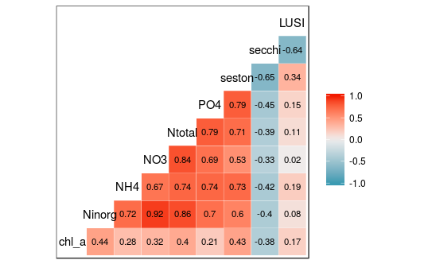

Not very significant, except between N species etc. which is hardly surprising.. Probably because for all the chemical concentrations, there is only one LUSI.

```
Missing values are imputed by the mean of the variable: you should use the imputePCA function of the missMDA package
```

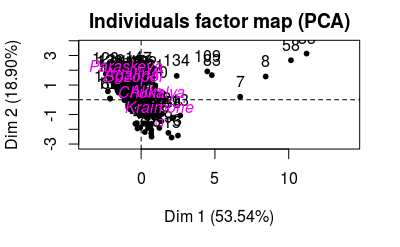

````r
```r
```r
## scale and center the reduced dataset
water.sand.all.LUSI.red.scaled <- scale(water.sand.all.LUSI.red,
                                   center = TRUE, scale = TRUE)
water.sand.all.LUSI.red.scaled <- bind_cols(water.sand.all.LUSI %>% select(station),
                                       as.tibble(water.sand.all.LUSI.red.scaled))
## perform the PCA
water.sand.all.LUSI.red.pca <- PCA(water.sand.all.LUSI.red.scaled, scale.unit = FALSE, quali.sup = 1)
````

```
-- creation of the .Rmd file (time spent : 0s) --

-- detection of outliers (time spent : 0.01s) --
3 outlier(s) terminated

-- analysis of the inertia (time spent : 0.11s) --
2 component(s) carrying information : total inertia of 68%

-- components description (time spent : 3.38s) --
plane 1:2
Chi-squared approximation may be incorrect

-- classification (time spent : 3.59s) --
Chi-squared approximation may be incorrect
3 clusters

-- annexes writing (time spent : 3.87s) --

-- saving data (time spent : 4.07s) --

-- outputs compilation (time spent : 4.1s) --
xdg-open: unexpected argument 'Passport/rabota/documents/phd/thesis/4-results-discussion/data-n-analyses/results-analysis/pca_water_sand_all_LUSI_red_report.html'
Try 'xdg-open --help' for more information.
-- task completed (time spent : 17.48s) --
This interpretation of the results was carried out automatically,
it cannot match the quality of a personal interpretation
```

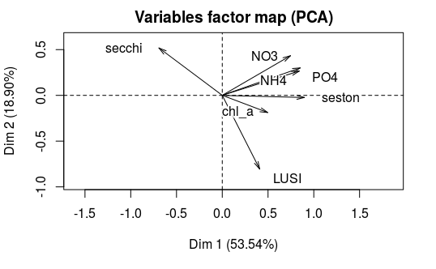

````r
```r
```r
Investigate(water.sand.all.LUSI.red.pca,
            file = \pca_water_sand_all_LUSI_red_report.Rmd\, document = \html_document\,
            out.selec = TRUE,
            remove.temp = TRUE)
````

````r
```r
```r
write_rds(water.sand.all.LUSI.red.pca,
          here(save.dir, \pca_water_sand_all_LUSI_red.RDS\))
````

Let’s try again with the **sediment parameters** - there are more values per station here, so should turn out better.

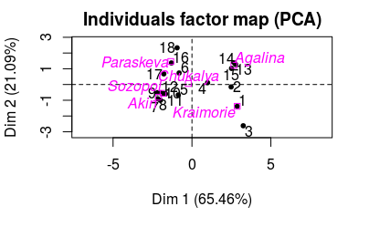

````r
```r
```r
# scale and center the data (different units), and add back the stations
sediments.sand.scaled <- scale(sediments.sand %>% select(-c(station:year)), center = TRUE, scale = TRUE)
sediments.sand.scaled <- bind_cols(sediments.sand %>% select(station),
                                   as.tibble(sediments.sand.scaled))
sediments.sand.pca <- PCA(sediments.sand.scaled, scale.unit = FALSE, quali.sup = 1)
````

```
-- creation of the .Rmd file (time spent : 0s) --

-- detection of outliers (time spent : 0.03s) --
0 outlier(s) terminated

-- analysis of the inertia (time spent : 0.04s) --
1 component(s) carrying information : total inertia of 65.5%

-- components description (time spent : 3.13s) --
dim. 1
Chi-squared approximation may be incorrect

-- classification (time spent : 3.47s) --
Chi-squared approximation may be incorrect
4 clusters

-- annexes writing (time spent : 3.72s) --

-- saving data (time spent : 3.76s) --

-- outputs compilation (time spent : 3.77s) --
xdg-open: unexpected argument 'Passport/rabota/documents/phd/thesis/4-results-discussion/data-n-analyses/results-analysis/pca_sediments_sand_report.html'
Try 'xdg-open --help' for more information.
-- task completed (time spent : 12.83s) --
This interpretation of the results was carried out automatically,
it cannot match the quality of a personal interpretation
```

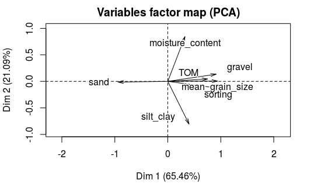

````r
```r
```r
Investigate(sediments.sand.pca, file = \pca_sediments_sand_report.Rmd\, document = \html_document\, remove.temp = TRUE)
````

*NB The knitting of the report fails if I try to put it in a subfolder of the working directory, so I’ll just move it by hand afterwards - it will live in the output directory.*

Save the sediment PCA, too, for posterity…

````r
```r
```r
write_rds(sediments.sand.pca,
          here(save.dir, \pca_sediments_sand.RDS\))
````

Now do it one more time, but first remove the most correlated variables from the sediment dataset.

````r
```r
```r
## calculate the correlation matrix (on the numeric variables only)
sediments.sand.cors <- cor(sediments.sand %>% select(-c(station:year)))

## find and eliminate the highly correlated variables. NB names = FALSE, to return column index
highly.cor.sediments.sand <- findCorrelation(sediments.sand.cors, cutoff = 0.85)
(sediments.sand.red <- sediments.sand %>%
    select(-c(station:year)) %>% # otherwise column indices don't match
    select(-highly.cor.sediments.sand)
)
````

| TOM | moisture_content | gravel | silt_clay |
| --- | --- | --- | --- |
| 2.668743 | 24.96006 | 29.2910811 | 7.4802569 |
| 2.320585 | 26.37882 | 34.4206293 | 4.0770747 |
| 3.016901 | 23.54131 | 24.1615329 | 10.8834391 |
| 1.707946 | 26.45092 | 19.3405824 | 2.6056875 |
| 1.668141 | 24.32821 | 10.4236320 | 4.2896917 |
| 1.747752 | 28.57363 | 11.4191048 | 2.0828084 |
| 1.284550 | 21.39787 | 2.0412727 | 3.4094221 |
| 1.216450 | 21.00996 | 1.2158865 | 2.7562485 |
| 1.352651 | 21.78578 | 0.3032171 | 1.8664750 |
| 1.510918 | 23.46939 | 0.9989210 | 3.2140111 |

[output cut: 8 more lines]

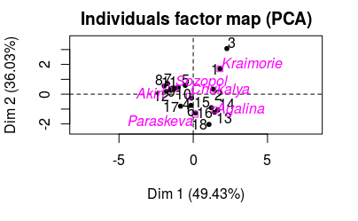

````r
```r
```r
# scale and center the data (different units), and add back the stations
sediments.sand.red.scaled <- scale(sediments.sand.red,
                                   center = TRUE, scale = TRUE)
sediments.sand.red.scaled <- bind_cols(sediments.sand %>% select(station),
                                       as.tibble(sediments.sand.red.scaled))
sediments.sand.red.pca <- PCA(sediments.sand.red.scaled, scale.unit = FALSE, quali.sup = 1)
````

[output not shown]

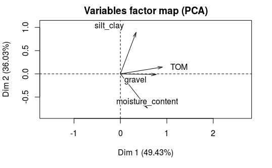

````r
```r
```r
Investigate(sediments.sand.red.pca,
            file = \pca_sediments_sand_red_report.Rmd\, document = \html_document\,
            out.selec = FALSE, # don't check for outliers; it breaks the analysis
            remove.temp = TRUE)
````

OK, with the reduced sediment dataset, the PCA turns out not significant at all. Because it wasn’t confusing enough to begin with…

I’ll save it anyway.

````r
```r
```r
write_rds(sediments.sand.red.pca,
          here(save.dir, \pca_sediments_sand_red.RDS\))
````

For the **heavy metals**, I think the wisest would be to calculate the total (new variable, sum of all heavy metals), calculate another variable - ratio of every metal to Fe, which is usually present naturally in the environment, and to keep only Pb and Cd - source - pollution from human activities.

**There are no national standards for environmental quality for heavy metals in sediments - these values are next to useless then. All I can say is at which station the concentration of Pb is higher, and some such.**

###### **Elastic net - sand stations, 2013-14**

First, let’s throw all parameters together and do stations as a dependent variable. This means the water column parameters will have to be repeated 3 times, and merged with the sediments & heavy metals.

````r
```r
```r
envir.en.sand <- left_join(sediments,
                           water.sand,
                           by = \station\)
## make station a factor
(envir.en.sand <- envir.en.sand %>%
    mutate(station = factor(station, levels = c(\Kraimorie\, \Chukalya\, \Akin\, \Sozopol\, \Agalina\, \Paraskeva\)))
)
````

| station | month | year | habitat | TOM | moisture_content | mean_grain_size | sorting | gravel | sand | silt_clay | Cu | Pb | Zn | Cd | Mn | Fe | Ni | Ntotal_mean | Ninorg_mean | NH4_mean | NO3_mean | PO4_mean | chl_a_mean | seston_mean | secchi_mean | O2 | O2_bottom | temperature | temperature_bottom | … |
| --- | --- | --- | --- | --- | --- | --- | --- | --- | --- | --- | --- | --- | --- | --- | --- | --- | --- | --- | --- | --- | --- | --- | --- | --- | --- | --- | --- | --- | --- | --- |
| Kraimorie | 6 | 2013 | S | 2.668743 | 24.96006 | 230.77015 | 4.827674 | 29.2910811 | 63.22866 | 7.4802569 | 38.390 | 33.801 | 45.599 | 3.475 | 350.843 | 13892.415 | 27.528 | 19.61 | 4.30 | 1.09 | 2.63 | 0.34 | 3.22 | 2.29 | 3.27 | 7.965667 | 5.9025 | 24.34278 | 22.72500 | … |
| Kraimorie | 9 | 2013 | S | 2.320585 | 26.37882 | 236.88379 | 4.300971 | 34.4206293 | 61.50230 | 4.0770747 | 38.390 | 33.801 | 45.599 | 3.475 | 350.843 | 13892.415 | 27.528 | 19.61 | 4.30 | 1.09 | 2.63 | 0.34 | 3.22 | 2.29 | 3.27 | 7.965667 | 5.9025 | 24.34278 | 22.72500 | … |
| Kraimorie | 7 | 2014 | S | 3.016901 | 23.54131 | 224.65650 | 5.354377 | 24.1615329 | 64.95503 | 10.8834391 | 38.390 | 33.801 | 45.599 | 3.475 | 350.843 | 13892.415 | 27.528 | 19.61 | 4.30 | 1.09 | 2.63 | 0.34 | 3.22 | 2.29 | 3.27 | 7.965667 | 5.9025 | 24.34278 | 22.72500 | … |
| Chukalya | 6 | 2013 | S | 1.707946 | 26.45092 | 223.11551 | 4.152526 | 19.3405824 | 78.05373 | 2.6056875 | 8.514 | 24.163 | 12.746 | 1.476 | 310.089 | 6258.415 | 5.364 | 19.21 | 4.01 | 0.96 | 2.35 | 0.32 | 3.09 | 2.42 | 4.39 | 7.629519 | 5.2025 | 23.23132 | 21.12500 | … |
| Chukalya | 9 | 2013 | S | 1.668141 | 24.32821 | 76.27143 | 1.860929 | 10.4236320 | 85.28668 | 4.2896917 | 8.514 | 24.163 | 12.746 | 1.476 | 310.089 | 6258.415 | 5.364 | 19.21 | 4.01 | 0.96 | 2.35 | 0.32 | 3.09 | 2.42 | 4.39 | 7.629519 | 5.2025 | 23.23132 | 21.12500 | … |
| Chukalya | 7 | 2014 | S | 1.747752 | 28.57363 | 76.76289 | 1.860489 | 11.4191048 | 86.49809 | 2.0828084 | 8.514 | 24.163 | 12.746 | 1.476 | 310.089 | 6258.415 | 5.364 | 19.21 | 4.01 | 0.96 | 2.35 | 0.32 | 3.09 | 2.42 | 4.39 | 7.629519 | 5.2025 | 23.23132 | 21.12500 | … |
| Akin | 6 | 2013 | S | 1.284550 | 21.39787 | 75.10534 | 1.122515 | 2.0412727 | 94.54931 | 3.4094221 | 15.060 | 31.113 | 22.366 | 1.491 | 359.294 | 13050.248 | 4.871 | 17.19 | 3.53 | 0.84 | 2.07 | 0.27 | 3.06 | 2.17 | 5.19 | 8.324065 | 7.5100 | 23.66838 | 21.20000 | … |
| Akin | 9 | 2013 | S | 1.216450 | 21.00996 | 75.08430 | 1.120519 | 1.2158865 | 96.02787 | 2.7562485 | 15.060 | 31.113 | 22.366 | 1.491 | 359.294 | 13050.248 | 4.871 | 17.19 | 3.53 | 0.84 | 2.07 | 0.27 | 3.06 | 2.17 | 5.19 | 8.324065 | 7.5100 | 23.66838 | 21.20000 | … |
| Akin | 7 | 2014 | S | 1.352651 | 21.78578 | 75.08513 | 1.118173 | 0.3032171 | 97.83031 | 1.8664750 | 15.060 | 31.113 | 22.366 | 1.491 | 359.294 | 13050.248 | 4.871 | 17.19 | 3.53 | 0.84 | 2.07 | 0.27 | 3.06 | 2.17 | 5.19 | 8.324065 | 7.5100 | 23.66838 | 21.20000 | … |
| Sozopol | 6 | 2013 | S | 1.510918 | 23.46939 | 74.98858 | 1.120851 | 0.9989210 | 95.78707 | 3.2140111 | 2.842 | 12.314 | 23.004 | 4.736 | 129.296 | 3190.189 | 1.691 | 17.56 | 3.42 | 0.66 | 2.57 | 0.17 | 2.72 | 1.48 | 6.35 | 8.323346 | 7.9925 | 23.98680 | 23.27500 | … |

[output cut: 8 more lines]

Despite everything I said before about substituting LUSI for all water column variables, I’m going to throw everything at the model and see how it does.  
First try: y = station  
It doesn’t work, because there are too few observtions per group, this being the summarized long-term water column data (commented out to allow knitting of the notebook).

````r
```r
```r
# en.st.sand <- glmnet(x = as.matrix(envir.en.sand %>% select(TOM:LUSI)),
#                      y = envir.en.sand %>% pull(station),
#                      family = \multinomial\, type.multinomial = \grouped\)
#
# plot(en.st.sand, xvar = \lambda\, label = TRUE, type.coef = \2norm\)
#
#
# cvfit.st.sand <- cv.glmnet(x = as.matrix(envir.en.sand %>% select(TOM:LUSI)),
#                            y = envir.en.sand %>% pull(station),
#                            family=\multinomial\, type.multinomial = \grouped\)
#
# plot(cvfit.st.sand)
````

So, glmnet fails because there are too few observations…  
I’ll try again with non-summarized data - for the water, this will essentially repeat Mitko’s PhD analyses, but what the hell, I have the computing power and I don’t care…  
The raw data come from the enivronmental data cleaning notebook; I’ll save them later to avoid repeating these steps, which I just did off the record..  
Starting with water column crap.

````r
```r
```r
## starting with the non-summarized water column data (imported several chunks above, because needed for trying PCA).
## remove row Paraskeva-2015 (the only one where seston is NaN) + variable secchi - has lots of NAs and NaNs which are not handled by glmnet
(water.sand.sub <- water.sand.all %>%
    filter(!(station == \Paraskeva\ & year == 2015)) %>%
    select(-secchi)
)
````

[figure not shown]

[output not shown]

[output cut: 140 more lines]

```r
## perform the elastic net shit
en.water.st.sand <- glmnet(x = as.matrix(water.sand.sub %>% select(chl_a:seston)),
                           y = water.sand.sub %>% pull(station),
                           family = \multinomial\, type.multinomial = \grouped\)
plot(en.water.st.sand, xvar = \lambda\, label = TRUE, type.coef = \2norm\)
```

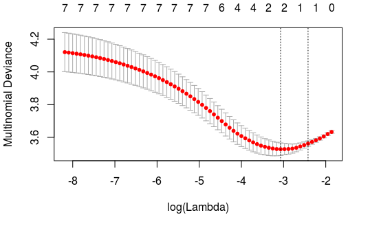

````r
```r
```r
cvfit.water.st.sand <- cv.glmnet(x = as.matrix(water.sand.sub %>% select(chl_a:seston)),
                                 y = water.sand.sub %>% pull(station),
                                 family=\multinomial\, type.multinomial = \grouped\)
plot(cvfit.water.st.sand)
````

All right, this is markedly better - no yelling, no complaints..  
Let’s see which variables are the most important according to the elastic net.

````r
```r
```r
coef(en.water.st.sand, s = cvfit.water.st.sand$lambda.min)
````

```
$Kraimorie
8 x 1 sparse Matrix of class \dgCMatrix\
                       1
(Intercept) -0.542058403
chl_a        .
Ninorg       .
NH4          .
NO3         -0.006280022
Ntotal       .
PO4          .
seston       0.327965212

$Chukalya
8 x 1 sparse Matrix of class \dgCMatrix\
                      1
(Intercept) -0.63323591
chl_a        .
Ninorg       .
NH4          .
NO3         -0.02115474
Ntotal       .
PO4          .
seston       0.38814637

$Akin
8 x 1 sparse Matrix of class \dgCMatrix\
                      1
(Intercept) -0.45149373
chl_a        .
Ninorg       .
NH4          .
NO3         -0.02043369
Ntotal       .
PO4          .
seston       0.30239299

$Sozopol
8 x 1 sparse Matrix of class \dgCMatrix\
                      1
(Intercept)  0.33729584
```

[output cut: 16 more lines]

```
Ntotal       .
PO4          .
seston      -0.37809916

$Paraskeva
8 x 1 sparse Matrix of class \dgCMatrix\
                       1
(Intercept)  0.695167793
chl_a        .
Ninorg       .
NH4          .
NO3          0.009635613
Ntotal       .
PO4          .
seston      -0.462667171
```

Seston and NO3 are the (apparent) winners. All right, I’ll try those..

````r
```r
```r
summary(glm(as.numeric(station) ~ NO3 + seston, data = water.sand.sub))
````

```
Call:
glm(formula = as.numeric(station) ~ NO3 + seston, data = water.sand.sub)

Deviance Residuals:
    Min       1Q   Median       3Q      Max
-3.7297  -1.0500   0.0725   1.2889   2.8489

Coefficients:
            Estimate Std. Error t value Pr(>|t|)
(Intercept)  4.31541    0.21788  19.806  < 2e-16 ***
NO3          0.13271    0.04797   2.766   0.0064 **
seston      -0.63475    0.11557  -5.492  1.7e-07 ***
---
Signif. codes:  0 ‘***’ 0.001 ‘**’ 0.01 ‘*’ 0.05 ‘.’ 0.1 ‘ ’ 1

(Dispersion parameter for gaussian family taken to be 2.434943)

    Null deviance: 431.47  on 149  degrees of freedom
Residual deviance: 357.94  on 147  degrees of freedom
AIC: 564.14

Number of Fisher Scoring iterations: 2
```

OK - the deviance drops between the null model and the actual model, although I couldn’t say how significant this is.  
For now, let’s pretend this is meaningful, and try again with the **sediment parameters minus the heavy metals**.

````r
```r
```r
en.sediments.st.sand <- glmnet(x = as.matrix(sediments.sand %>% select(TOM:silt_clay)),
                               y = sediments.sand %>% pull(station),
                               family = \multinomial\, type.multinomial = \grouped\)
````

```
one multinomial or binomial class has fewer than 8  observations; dangerous groundfrom glmnet Fortran code (error code -41); Convergence for 41th lambda value not reached after maxit=100000 iterations; solutions for larger lambdas returned
```

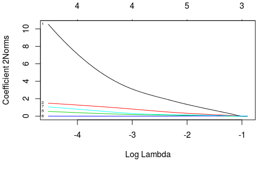

````r
```r
```r
plot(en.sediments.st.sand, xvar = \lambda\, label = TRUE, type.coef = \2norm\)
````

````r
```r
```r
cvfit.sediments.st.sand <- cv.glmnet(x = as.matrix(sediments.sand %>% select(TOM:silt_clay)),
                                     y = sediments.sand %>% pull(station),
                                     family=\multinomial\, type.multinomial = \grouped\)
````

```
one multinomial or binomial class has fewer than 8  observations; dangerous groundfrom glmnet Fortran code (error code -41); Convergence for 41th lambda value not reached after maxit=100000 iterations; solutions for larger lambdas returnedone multinomial or binomial class has fewer than 8  observati…
```

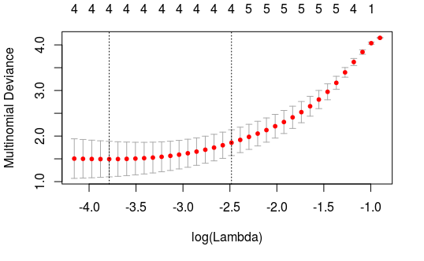

````r
```r
```r
plot(cvfit.sediments.st.sand)
````

Multiple issues: <8 observations per class - doubtful validity of the results; no convergence for lambda after 100000 iterations; solutions for larger lambdas returned (?).  
However, the algorithm does return something - let’s check it out… It thinks 4 variables best explain the variability between stations.

````r
```r
```r
coef(en.sediments.st.sand, s = cvfit.sediments.st.sand$lambda.min)
````

```
$Agalina
8 x 1 sparse Matrix of class \dgCMatrix\
                           1
(Intercept)      -17.5230073
TOM                0.2038929
moisture_content   0.5388098
mean_grain_size    .
sorting            .
gravel             0.2042252
sand               .
silt_clay         -0.2601345

$Akin
8 x 1 sparse Matrix of class \dgCMatrix\
                           1
(Intercept)      29.12592323
TOM              -4.24209185
moisture_content -0.86940051
mean_grain_size   .
sorting           .
gravel           -0.02639595
sand              .
silt_clay        -0.13048766

$Chukalya
8 x 1 sparse Matrix of class \dgCMatrix\
                           1
(Intercept)      -3.75176298
TOM              -1.48765884
moisture_content  0.28559595
mean_grain_size   .
sorting           .
gravel            0.04865473
sand              .
silt_clay         0.25269857

$Kraimorie
8 x 1 sparse Matrix of class \dgCMatrix\
                          1
(Intercept)      -4.2487166
```

[output cut: 16 more lines]

```
gravel            -0.1669386
sand               .
silt_clay         -0.4195305

$Sozopol
8 x 1 sparse Matrix of class \dgCMatrix\
                          1
(Intercept)       6.7751735
TOM               0.6053770
moisture_content -0.2184340
mean_grain_size   .
sorting           .
gravel           -0.1867500
sand              .
silt_clay         0.2569211
```

````r
```r
```r
summary(glm(as.numeric(as.factor(station)) ~ TOM + moisture_content + gravel + silt_clay, data = sediments.sand))
````

```
Call:
glm(formula = as.numeric(as.factor(station)) ~ TOM + moisture_content +
    gravel + silt_clay, data = sediments.sand)

Deviance Residuals:
    Min       1Q   Median       3Q      Max
-1.7403  -0.7271  -0.1721   0.6325   2.0832

Coefficients:
                 Estimate Std. Error t value Pr(>|t|)
(Intercept)       0.88592    4.60878   0.192  0.85054
TOM               1.42595    2.25228   0.633  0.53764
moisture_content  0.03537    0.26747   0.132  0.89681
gravel           -0.09029    0.02460  -3.670  0.00283 **
silt_clay         0.09769    0.41660   0.234  0.81826
---
Signif. codes:  0 ‘***’ 0.001 ‘**’ 0.01 ‘*’ 0.05 ‘.’ 0.1 ‘ ’ 1

(Dispersion parameter for gaussian family taken to be 1.887858)

    Null deviance: 52.500  on 17  degrees of freedom
Residual deviance: 24.542  on 13  degrees of freedom
AIC: 68.662

Number of Fisher Scoring iterations: 2
```

Well, despite all reservations, I’m going to try and see how well these do in envfit etc. to explain the variability of the macrozoobenthic communities themselves.

Finally, I’ll try with **habitats** as the dependent variable. Essentially, these are the groups that also come from the cluster analysis of community composition - so maybe it’s more accurate to say they are the biotopes.  
This is only relevant for the sand communities (2013-2014) - the seagrasses are all one habitat/biotope, and 2012 are not so distinct (and the data are shitty).  
Whatever. I’m defining them by hand, then joining them to each dataset (water and sediments), and redoing the analyses.

````r
```r
```r
## define the habitats (biotopes) = clusters from the MDS and other community structure analyses
(habitats.sand <- tibble(station = c(\Kraimorie\, \Chukalya\, \Akin\, \Sozopol\, \Agalina\, \Paraskeva\),
                         habitat = c(1, 1, 2, 3, 4, 3))
 )
````

| station | habitat |
| --- | --- |
| Kraimorie | 1 |
| Chukalya | 1 |
| Akin | 2 |
| Sozopol | 3 |
| Agalina | 4 |
| Paraskeva | 3 |

Now perform the elastic net analysis using the non-summarized water column data (first adding the habitats to the dataset).

````r
```r
```r
## add habitats to water column (non-summarized) dataset
(water.sand.sub.hab <- left_join(water.sand.sub,
                                 habitats.sand,
                                 by = \station\)
)
````

```
Column `station` joining factor and character vector, coercing into character vector
```

[figure not shown]

| station | year | month | chl_a | Ninorg | NH4 | NO3 | Ntotal | PO4 | seston | habitat |
| --- | --- | --- | --- | --- | --- | --- | --- | --- | --- | --- |
| Agalina | 2009 | 7 | 1.0033333 | 1.9666667 | 0.316666667 | 1.6106667 | 6.388000 | 0.15900000 | 0.6200000 | 4 |
| Agalina | 2009 | 8 | 0.2353333 | 1.3110000 | 0.316666667 | 0.9650000 | 18.470000 | 0.21400000 | 0.7533333 | 4 |
| Agalina | 2009 | 9 | 1.3693333 | 1.5060000 | 0.416666667 | 1.0423333 | 14.386667 | 0.15400000 | 0.4866667 | 4 |
| Agalina | 2009 | 10 | 1.4063333 | 1.3380000 | 0.316666667 | 0.7046667 | 17.894667 | 0.20900000 | 0.9600000 | 4 |
| Agalina | 2009 | 11 | 4.1256667 | 1.6330000 | 0.550000000 | 1.0210000 | 17.266333 | 0.22400000 | 1.4133333 | 4 |
| Agalina | 2009 | 12 | 3.2543333 | 1.2646667 | 0.383333333 | 0.8150000 | 19.130667 | 0.08000000 | 1.1733333 | 4 |
| Agalina | 2010 | 1 | 0.0000000 | 0.0000000 | 0.000000000 | 0.0000000 | 0.000000 | 0.00000000 | 0.0000000 | 4 |
| Agalina | 2010 | 2 | 7.1693333 | 17.5730000 | 1.900000000 | 14.9166667 | 40.947667 | 1.32833333 | 3.2733333 | 4 |
| Agalina | 2010 | 3 | 3.2336667 | 6.4326667 | 0.633333333 | 5.4863333 | 23.170667 | 0.19400000 | 1.3400000 | 4 |
| Agalina | 2010 | 4 | 2.3736667 | 7.3930000 | 0.683333333 | 6.3470000 | 23.166667 | 0.08500000 | 1.2866667 | 4 |

[output cut: 140 more lines]

````r
```r
```r
## make habitat a factor
water.sand.sub.hab <- water.sand.sub.hab %>%
  mutate(habitat = factor(habitat))
## perform the elastic net with habitat as dependent variable
en.water.hab.sand <- glmnet(x = as.matrix(water.sand.sub.hab %>% select(chl_a:seston)),
                            y = water.sand.sub.hab %>% pull(habitat),
                            family = \multinomial\, type.multinomial = \grouped\)
plot(en.water.hab.sand, xvar = \lambda\, label = TRUE, type.coef = \2norm\)
````

[figure not shown]

````r
```r
```r
cvfit.water.hab.sand <- cv.glmnet(x = as.matrix(water.sand.sub.hab %>% select(chl_a:seston)),
                                  y = water.sand.sub.hab %>% pull(habitat),
                                  family=\multinomial\, type.multinomial = \grouped\)
plot(cvfit.water.hab.sand)
````

Wow, no complaints here - what’s going on?!

````r
```r
```r
coef(en.water.hab.sand, s = cvfit.water.hab.sand$lambda.min)
````

```
$`1`
8 x 1 sparse Matrix of class \dgCMatrix\
                        1
(Intercept) -0.4690206211
chl_a        .
Ninorg       .
NH4          .
NO3         -0.0567029678
Ntotal      -0.0004377111
PO4          .
seston       0.5536572769

$`2`
8 x 1 sparse Matrix of class \dgCMatrix\
                        1
(Intercept) -0.9544108788
chl_a        .
Ninorg       .
NH4          .
NO3         -0.0534310100
Ntotal      -0.0009726862
PO4          .
seston       0.4588778309

$`3`
8 x 1 sparse Matrix of class \dgCMatrix\
                       1
(Intercept)  1.056958151
chl_a        .
Ninorg       .
NH4          .
NO3          0.055899876
Ntotal       0.000438441
PO4          .
seston      -0.503693276

$`4`
8 x 1 sparse Matrix of class \dgCMatrix\
                        1
(Intercept)  0.3664733486
chl_a        .
Ninorg       .
NH4          .
NO3          0.0542341017
Ntotal       0.0009719563
PO4          .
seston      -0.5088418316
```

Hm, NO3 and seston again. Great!  
Let’s check out what the model says.

````r
```r
```r
summary(glm(as.numeric(as.factor(habitat)) ~ NO3 + seston, data = water.sand.sub.hab))
````

```
Call:
glm(formula = as.numeric(as.factor(habitat)) ~ NO3 + seston,
    data = water.sand.sub.hab)

Deviance Residuals:
    Min       1Q   Median       3Q      Max
-2.2006  -0.8824   0.1294   0.7021   1.7877

Coefficients:
            Estimate Std. Error t value Pr(>|t|)
(Intercept)  2.87145    0.14126  20.328  < 2e-16 ***
NO3          0.09564    0.03110   3.075  0.00251 **
seston      -0.42472    0.07493  -5.668 7.38e-08 ***
---
Signif. codes:  0 ‘***’ 0.001 ‘**’ 0.01 ‘*’ 0.05 ‘.’ 0.1 ‘ ’ 1

(Dispersion parameter for gaussian family taken to be 1.023442)

    Null deviance: 183.33  on 149  degrees of freedom
Residual deviance: 150.45  on 147  degrees of freedom
AIC: 434.13

Number of Fisher Scoring iterations: 2
```

Now, fingers crossed for the sediments.

````r
```r
```r
## add the habitats to the sediment dataset
sediments.sand.hab <- left_join(sediments.sand,
                                habitats.sand,
                                by = \station\)
## convert habitat to factor
sediments.sand.hab <- sediments.sand.hab %>%
  mutate(habitat = factor(habitat))
en.sediments.hab.sand <- glmnet(x = as.matrix(sediments.sand.hab %>%
                                                select(TOM:silt_clay)),
                                y = sediments.sand.hab %>% pull(habitat),
                                family = \multinomial\, type.multinomial = \grouped\)
````

```
one multinomial or binomial class has fewer than 8  observations; dangerous groundfrom glmnet Fortran code (error code -46); Convergence for 46th lambda value not reached after maxit=100000 iterations; solutions for larger lambdas returned
```

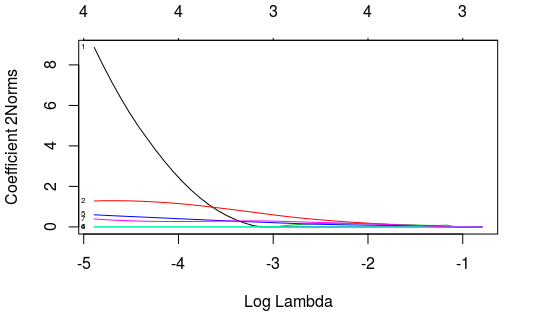

````r
```r
```r
plot(en.sediments.hab.sand, xvar = \lambda\, label = TRUE, type.coef = \2norm\)
````

````r
```r
```r
# cvfit.sediments.hab.sand <- cv.glmnet(x = as.matrix(sediments.sand.hab %>% select(TOM:silt_clay)),
#                                       y = sediments.sand.hab %>% pull(habitat),
#                                       family=\multinomial\, type.multinomial = \grouped\)
#
# plot(cvfit.sediments.hab.sand)
````

````r
```r
```r
# coef(en.sediments.hab.sand, s = cvfit.sediments.hab.sand$lambda.min)
````

Test the model.

````r
```r
```r
summary(glm(as.numeric(as.factor(habitat)) ~ TOM + moisture_content + gravel + silt_clay, data = sediments.sand.hab))
````

```
Call:
glm(formula = as.numeric(as.factor(habitat)) ~ TOM + moisture_content +
    gravel + silt_clay, data = sediments.sand.hab)

Deviance Residuals:
    Min       1Q   Median       3Q      Max
-1.5749  -0.4188   0.1532   0.6813   1.2054

Coefficients:
                  Estimate Std. Error t value Pr(>|t|)
(Intercept)       2.680120   3.375831   0.794    0.441
TOM               0.347959   1.649744   0.211    0.836
moisture_content -0.006434   0.195918  -0.033    0.974
gravel            0.011559   0.018021   0.641    0.532
silt_clay        -0.317585   0.305147  -1.041    0.317

(Dispersion parameter for gaussian family taken to be 1.012883)

    Null deviance: 22.000  on 17  degrees of freedom
Residual deviance: 13.167  on 13  degrees of freedom
AIC: 57.455

Number of Fisher Scoring iterations: 2
```

No significant variables - mostly expected, without convergence and all.

More or less the same results with the habitats as dependent variable (with the same statistical problems).

##### Seagrass stations - Burgas Bay (2013-2014)

Now I’ll analyze the seagrass stations - mostly focusing on the sediment parameters, because I strongly suspect the same piece of shit will happen if I try with the very much summarized water column variables.

Filter water column data anyway, in case I decide to do something with it.

````r
```r
```r
## filter (manually) to get only the zostera 2013-2014 stations - mean data & convert station to factor
(water.zostera <- water %>%
    filter(station %in% c(\Poda\, \Otmanli\, \Vromos\, \Gradina\, \Ropotamo\)) %>%
   mutate(station = factor(station, levels = c(\Poda\, \Otmanli\, \Vromos\, \Gradina\, \Ropotamo\))) %>%
   arrange(station)
)
````

```r
## also filter the non-summarized water column data & arrange by station!
(water.zostera.all <- water.all %>%
    filter(station %in% c(\Poda\, \Otmanli\, \Vromos\, \Gradina\, \Ropotamo\)) %>%
   mutate(station = factor(station, levels = c(\Poda\, \Otmanli\, \Vromos\, \Gradina\, \Ropotamo\))) %>%
   arrange(station)
)
```

````
```r
```r
## ... and import the pseudo-manipulated-long-term data for the seagrasses
(water.zostera.LT <- read_csv(here(save.dir, \water_colmumn_raw_LT_seagrass.csv\)) %>%
   mutate(station = factor(station, levels = c(\Poda\, \Otmanli\, \Vromos\, \Gradina\, \Ropotamo\))) %>%
   arrange(station)
)
````

| station | Ntotal_mean | Ninorg_mean | NH4_mean | NO3_mean | PO4_mean | chl_a_mean | seston_mean | secchi_mean | O2 | O2_bottom | temperature | temperature_bottom |
| --- | --- | --- | --- | --- | --- | --- | --- | --- | --- | --- | --- | --- |
| Poda | 22.46 | 2.74 | 0.91 | 1.75 | 0.70 | 4.47 | 2.55 | 3.00 | 7.774048 | 6.713333 | 25.10381 | 24.500 |
| Otmanli | 20.08 | 2.08 | 0.64 | 1.37 | 0.23 | 3.67 | 1.86 | 4.25 | 8.103500 | 7.120000 | 23.01500 | 22.350 |
| Vromos | 16.70 | 1.84 | 0.71 | 1.08 | 0.24 | 3.49 | 1.95 | NaN | NA | NA | NA | NA |
| Gradina | 18.26 | 2.22 | 0.60 | 1.57 | 0.14 | 3.02 | 1.44 | 5.50 | 8.468000 | 8.717500 | 21.13280 | 20.775 |
| Ropotamo | 23.78 | 5.34 | 0.87 | 4.38 | 0.43 | 4.73 | 2.33 | 6.38 | 8.434554 | 9.800000 | 22.14018 | 21.550 |

| station | month | year | depth | chl_a | Ninorg | NH4 | NO3 | Ntotal | PO4 | seston | secchi |
| --- | --- | --- | --- | --- | --- | --- | --- | --- | --- | --- | --- |
| Poda | 7 | 2009 | 0 | 0.000 | 1.031 | 0.50 | 0.500 | 0.000 | 0.149 | 1.800 | 3.0 |
| Poda | 7 | 2009 | 3 | 2.149 | 0.949 | 0.50 | 0.432 | 4.778 | 0.149 | 1.140 | 3.0 |
| Poda | 7 | 2009 | 9 | 0.000 | 1.226 | 0.75 | 0.445 | 4.436 | 0.149 | 1.500 | 3.0 |
| Poda | 8 | 2009 | 0 | 0.000 | 1.316 | 0.50 | 0.764 | 9.747 | 0.164 | 0.460 | 1.5 |
| Poda | 8 | 2009 | 3 | 2.815 | 1.439 | 0.45 | 0.936 | 14.030 | 0.179 | 1.280 | 1.5 |
| Poda | 8 | 2009 | 9 | 0.000 | 1.316 | 0.45 | 0.814 | 15.359 | 0.179 | 2.960 | 1.5 |
| Poda | 9 | 2009 | 0 | 5.797 | 1.948 | 0.85 | 1.036 | 19.383 | 0.239 | 4.200 | 1.5 |
| Poda | 9 | 2009 | 3 | 3.191 | 2.007 | 0.85 | 1.091 | 14.333 | 0.239 | 8.220 | 1.5 |
| Poda | 9 | 2009 | 9 | 5.830 | 1.953 | 0.90 | 0.995 | 14.606 | 0.254 | 3.980 | 1.5 |
| Poda | 10 | 2009 | 0 | 1.230 | 1.035 | 0.40 | 0.586 | 17.680 | 0.149 | 0.900 | 3.0 |

[output cut: 349 more lines]

Import the **summarized** sediment data (it also contains the heavy metals).

````r
```r
```r
sediments.zostera <- read_csv(here(save.dir, \sediments_imputed_seagrass.csv\)) %>%
    ## convert station to factor and arrange by it
   mutate(station = factor(station, levels = c(\Poda\, \Otmanli\, \Vromos\, \Gradina\, \Ropotamo\))) %>%
   arrange(station)
```r
```r
## split into sediment parameters sesnu stricto, and heavy metals
(heavy.metals.zostera <- sediments.zostera %>%
    select(station:year, Cu:Ni)
)
````

```r
(sediments.zostera <- sediments.zostera %>%
    select(-c(Cu:Ni))
)
```

| station | month | year | habitat | TOM | moisture_content | mean_grain_size | sorting | gravel | sand | silt_clay |
| --- | --- | --- | --- | --- | --- | --- | --- | --- | --- | --- |
| Poda | 6 | 2013 | Z | 2.140068 | 27.09861 | 74.44179 | 1.339402 | 2.719866 | 88.85319 | 8.426947 |
| Poda | 7 | 2014 | Z | 2.120016 | 26.61388 | 73.86700 | 1.431000 | 2.054323 | 86.56654 | 11.379133 |
| Otmanli | 6 | 2013 | Z | 1.891948 | 28.28708 | 74.90162 | 2.128386 | 5.414437 | 86.59910 | 7.986467 |
| Otmanli | 7 | 2014 | Z | 2.374579 | 24.90324 | 75.68377 | 1.821531 | 6.142087 | 90.29371 | 3.564200 |
| Vromos | 7 | 2014 | Z | 2.695494 | 25.13377 | 75.13955 | 1.119535 | 1.035772 | 96.77527 | 2.188962 |
| Gradina | 6 | 2013 | Z | 1.374342 | 25.60239 | 75.04728 | 1.121080 | 1.297130 | 95.60772 | 3.095146 |
| Gradina | 7 | 2014 | Z | 1.258799 | 25.35220 | 75.29806 | 1.119141 | 1.456179 | 97.07795 | 1.465872 |
| Ropotamo | 6 | 2013 | Z | 2.102018 | 26.69420 | 218.89466 | 4.098685 | 16.558171 | 80.66193 | 2.779903 |

Add LUSI to the water column data for the seagrass stations.

````r
```r
```r
## match by station - only for the seagrass stations - the rows of x (the water column data) where there are matching values in y (LUSI) -> e.g. inner join
(water.zostera <- inner_join(water.zostera,
                             lusi %>% select(-watershed),
                             by = \station\) %>%
    ## convert station back to factor
   mutate(station = factor(station, levels = c(\Poda\, \Otmanli\, \Vromos\, \Gradina\, \Ropotamo\))) %>%
   arrange(station)
)
````

```
Column `station` joining factor and character vector, coercing into character vector
```

| station | Ntotal_mean | Ninorg_mean | NH4_mean | NO3_mean | PO4_mean | chl_a_mean | seston_mean | secchi_mean | O2 | O2_bottom | temperature | temperature_bottom | LUSI |
| --- | --- | --- | --- | --- | --- | --- | --- | --- | --- | --- | --- | --- | --- |
| Poda | 22.46 | 2.74 | 0.91 | 1.75 | 0.70 | 4.47 | 2.55 | 3.00 | 7.774048 | 6.713333 | 25.10381 | 24.500 | 6.25 |
| Otmanli | 20.08 | 2.08 | 0.64 | 1.37 | 0.23 | 3.67 | 1.86 | 4.25 | 8.103500 | 7.120000 | 23.01500 | 22.350 | 6.25 |
| Vromos | 16.70 | 1.84 | 0.71 | 1.08 | 0.24 | 3.49 | 1.95 | NaN | NA | NA | NA | NA | 4.00 |
| Gradina | 18.26 | 2.22 | 0.60 | 1.57 | 0.14 | 3.02 | 1.44 | 5.50 | 8.468000 | 8.717500 | 21.13280 | 20.775 | 3.75 |
| Ropotamo | 23.78 | 5.34 | 0.87 | 4.38 | 0.43 | 4.73 | 2.33 | 6.38 | 8.434554 | 9.800000 | 22.14018 | 21.550 | 2.50 |

Check the correlations here, too, just for the heck of it (correlations with only single values are just as meaningless as PCA)..

````r
```r
```r
Hmisc::rcorr(as.matrix(water.zostera %>% select(-station)),
             type = \pearson\)
````

```
                   Ntotal_mean Ninorg_mean NH4_mean
Ntotal_mean               1.00        0.81     0.77
Ninorg_mean               0.81        1.00     0.63
NH4_mean                  0.77        0.63     1.00
NO3_mean                  0.78        1.00     0.56
PO4_mean                  0.72        0.39     0.93
chl_a_mean                0.90        0.78     0.93
seston_mean               0.74        0.51     0.96
secchi_mean               0.03        0.61    -0.20
O2                       -0.26        0.36    -0.45
O2_bottom                 0.18        0.73     0.00
temperature               0.47       -0.14     0.64
temperature_bottom        0.44       -0.16     0.64
LUSI                     -0.01       -0.58    -0.02
                   NO3_mean PO4_mean chl_a_mean
Ntotal_mean            0.78     0.72       0.90
Ninorg_mean            1.00     0.39       0.78
NH4_mean               0.56     0.93       0.93
NO3_mean               1.00     0.31       0.72
PO4_mean               0.31     1.00       0.83
chl_a_mean             0.72     0.83       1.00
seston_mean            0.44     0.93       0.93
secchi_mean            0.68    -0.53      -0.06
O2                     0.45    -0.72      -0.34
O2_bottom              0.78    -0.34       0.09
temperature           -0.23     0.85       0.55
temperature_bottom    -0.25     0.86       0.52
LUSI                  -0.63     0.31      -0.04
                   seston_mean secchi_mean    O2
Ntotal_mean               0.74        0.03 -0.26
Ninorg_mean               0.51        0.61  0.36
NH4_mean                  0.96       -0.20 -0.45
NO3_mean                  0.44        0.68  0.45
PO4_mean                  0.93       -0.53 -0.72
chl_a_mean                0.93       -0.06 -0.34
seston_mean               1.00       -0.36 -0.60
secchi_mean              -0.36        1.00  0.96
O2                       -0.60        0.96  1.00
O2_bottom                -0.19        0.97  0.89
temperature               0.77       -0.87 -0.97
```

[output cut: 145 more lines]

```
LUSI               0.0075    0.2694
                   temperature_bottom LUSI
Ntotal_mean        0.5554             0.9852
Ninorg_mean        0.8390             0.3005
NH4_mean           0.3604             0.9735
NO3_mean           0.7503             0.2595
PO4_mean           0.1428             0.6135
chl_a_mean         0.4765             0.9473
seston_mean        0.2412             0.7796
secchi_mean        0.1215             0.0618
O2                 0.0255             0.1362
O2_bottom          0.2292             0.0075
temperature        0.0021             0.2694
temperature_bottom                    0.2706
LUSI               0.2706
```

Hm, no luck here: no signifcant correlations of LUSI with anything but the bottom O2, which itself is very unreliable. I suppose this difference with the sand stations is due to the fact that the “long-term” water column data for the seagrasses only spans 2013-2014/2015 - it’s not even close to the monthly data available for the sand stations over 2009-2011, supplemented with some data from 2013-2014.  
In essence, the available water column data for the seagrasses doesn’t really capture the anthropogenic eutrophication gradient (it’s the same Burgas Bay gradient as the sand stations).  
Could also explain why there are very, very few significant correlations at all…

For maximum fun, let’s try these correlations with **non-summarized water data** for the seagrass stations..

````r
```r
```r
Hmisc::rcorr(as.matrix(inner_join(water.zostera.all,
                             lusi %>% select(-watershed),
                             by = \station\) %>%
                         select(-c(station:month))),
             type = \pearson\)
````

```
Column `station` joining factor and character vector, coercing into character vector
       chl_a Ninorg  NH4   NO3 Ntotal   PO4 seston
chl_a   1.00   0.24 0.21  0.23  -0.05  0.24   0.30
Ninorg  0.24   1.00 0.62  0.99   0.43  0.18   0.65
NH4     0.21   0.62 1.00  0.52   0.32  0.08   0.36
NO3     0.23   0.99 0.52  1.00   0.40  0.19   0.66
Ntotal -0.05   0.43 0.32  0.40   1.00  0.18   0.18
PO4     0.24   0.18 0.08  0.19   0.18  1.00   0.68
seston  0.30   0.65 0.36  0.66   0.18  0.68   1.00
secchi -0.33  -0.15 0.27 -0.19   0.27 -0.41  -0.46
LUSI    0.06  -0.20 0.05 -0.22   0.04  0.19   0.15
       secchi  LUSI
chl_a   -0.33  0.06
Ninorg  -0.15 -0.20
NH4      0.27  0.05
NO3     -0.19 -0.22
Ntotal   0.27  0.04
PO4     -0.41  0.19
seston  -0.46  0.15
secchi   1.00 -0.38
LUSI    -0.38  1.00

n
       chl_a Ninorg NH4 NO3 Ntotal PO4 seston secchi
chl_a     31     31  31  31     31  31     31     22
Ninorg    31     31  31  31     31  31     31     22
NH4       31     31  31  31     31  31     31     22
NO3       31     31  31  31     31  31     31     22
Ntotal    31     31  31  31     31  31     31     22
PO4       31     31  31  31     31  31     31     22
seston    31     31  31  31     31  31     31     22
secchi    22     22  22  22     22  22     22     22
LUSI      31     31  31  31     31  31     31     22
       LUSI
chl_a    31
Ninorg   31
NH4      31
NO3      31
Ntotal   31
PO4      31
```

[output cut: 10 more lines]

```
Ntotal 0.8074 0.0170 0.0755 0.0244        0.3265
PO4    0.1894 0.3388 0.6878 0.3153 0.3265
seston 0.1033 0.0000 0.0493 0.0000 0.3362 0.0000
secchi 0.1308 0.5177 0.2326 0.3879 0.2221 0.0589
LUSI   0.7647 0.2909 0.7745 0.2250 0.8485 0.3119
       seston secchi LUSI
chl_a  0.1033 0.1308 0.7647
Ninorg 0.0000 0.5177 0.2909
NH4    0.0493 0.2326 0.7745
NO3    0.0000 0.3879 0.2250
Ntotal 0.3362 0.2221 0.8485
PO4    0.0000 0.0589 0.3119
seston        0.0321 0.4180
secchi 0.0321        0.0778
LUSI   0.4180 0.0778
```

Well not a significant improvement (maybe because LUSI only has a single value per station).

OK, let’s proceed with the sediment PCA. I’m not even going to bother eliminating highly correlated variables, that’s how useless I think this whole exercise is.

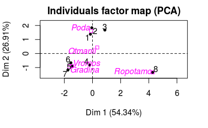

````r
```r
```r
# scale and center the data (different units), and add back the stations
sediments.zostera.scaled <- scale(sediments.zostera %>% select(-c(station:habitat)),
                                  center = TRUE, scale = TRUE)
sediments.zostera.scaled <- bind_cols(sediments.zostera %>% select(station),
                                      as.tibble(sediments.zostera.scaled))
# ## convert stations into factor, because for some stations there are more observations than for others, which causes the Investigate function to freak out later
# sediments.zostera.scaled <- sediments.zostera.scaled %>%
#   mutate(station = factor(station, levels = c(\Poda\, \Otmanli\, \Vromos\, \Gradina\, \Ropotamo\))) %>%
#   arrange(station)
sediments.zostera.pca <- PCA(sediments.zostera.scaled, scale.unit = FALSE, quali.sup = 1)
````

[output not shown]

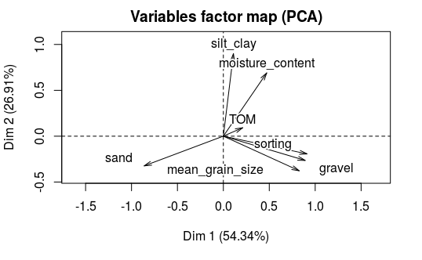

````r
```r
```r
Investigate(sediments.zostera.pca, file = \pca_sediments_zostera_report.Rmd\, document = \html_document\, remove.temp = TRUE)
````

Report summary: While the amount of variation explained by the first two PCs is significant, the estimation of the right number of axis to interpret suggests to **not interpret the analysis at all**: the amount of inertia of the first axis is not higher than that obtained by the 0.95-quantile of random distributions (54.34% against 54.9%); therefore no axis is carrying real information.  
I am going to blame this on the singleton values for Vromos and Ropotamo (only sampled once each during the study period).  
Anyway, because the suggestion is based on a value actually very close to being significant, here’s a very cautious, very tentative description of the first two dimensions, the clusters of individuals & the main explanatory variables.

Dimension 1 opposes individuals such as 8 (Ropotamo - to the right of the graph, characterized by a strongly positive coordinate on the axis) to individuals such as 7 (Gradina - to the left of the graph, characterized by a strongly negative coordinate on the axis). The group of individual 8 has high values for the variables mean_grain_size, sorting and gravel (strongest to weakest).  
The group of individual 7 has: - high values for the variable sand.  
- low values for the variables moisture_content and silt_clay (weakest to strongest).

Variables sorting, gravel and Ropotamo are highly correlated with this dimension (respective correlation of 0.95, 0.91, 0.91) - could summarize themselves the dimension 1.

Variables silt_clay and Poda are highly correlated with this dimension (respective correlation of 0.01, 0 - *wow..*). These variables could therefore summarize themselves the dimension 2.

The classification made on individuals reveals **4 clusters**.  
Cluster 1 is made of individuals such as 7 (Gradina), with low values for the variable TOM.  
Cluster 2 is made of individuals (Otmanli - one of the samples) with variables whose values do not differ significantly from the mean.  
Cluster 3 is made of individuals such as 1, 2 and 3 (Poda, other Otmanli), with high values for the variables silt_clay and moisture_content (strongest to weakest).  
Cluster 4 is made of individuals such as 8 (Ropotamo), with high values for the variables mean_grain_size, sorting and gravel (strongest to weakest).

In essence, based on the sediment structure and composition, Ropotamo is very different than the other seagrass stations - has coarser sediments, with more gravel and large mean grain size. The silt-clay and the TOM content are not so high, though - even though it could be expected, with the river mouth right there..  
Poda (and partially Otmanli) have very large silt-clay contents, which puts them in a group of their own. In passing, the two Otmanli values for the 2 years are very, very different…  
Gradina and Vromos are similar in sediment composition & structure - low silt-clay, high sand content.

Also save the seagrass sediment PCA, despite its doubtful usability…

````r
```r
```r
write_rds(sediments.zostera.pca,
          here(save.dir, \pca_sediments_zostera.RDS\))
````

For consistency, I’ll do a quick PCA on **non-summarized water column data** in seagrass.  
First - without removing any variables, even if they’re highly inter-correlated.

```
Missing values are imputed by the mean of the variable: you should use the imputePCA function of the missMDA package
```

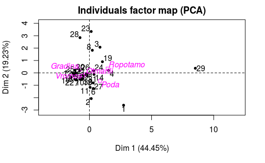

````r
```r
```r
## scale and center the data
water.zostera.all.scaled <- scale(water.zostera.all %>% select(-c(station:month)),
                                  center = TRUE, scale = TRUE)
water.zostera.all.scaled <- bind_cols(water.zostera.all %>% select(station),
                                      as.tibble(water.zostera.all.scaled))
water.zostera.all.pca <- PCA(water.zostera.all.scaled, scale.unit = FALSE, quali.sup = 1)
````

[output not shown]

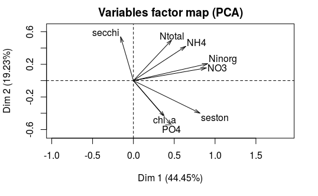

````r
```r
```r
Investigate(water.zostera.all.pca,
            file = \pca_water_zostera_all_report.Rmd\, document = \html_document\,
            out.selec = FALSE, # NB if outlier detection is performed, the function fails miserably, and I can't see a way to fix it
            remove.temp = TRUE)
````

OK, since the outlier check is omitted, the (previous, failed) report shows that three rows with extreme values have a really high influence on the axes, the separation, etc. These are rows 1 (Poda), 23 (Gradina) and 29 (Ropotamo). Let’s see them:

````r
```r
```r
water.zostera.all %>% filter(row_number() %in% c(1, 23, 29))
````

| station | year | month | chl_a | Ninorg | NH4 | NO3 | Ntotal | PO4 | seston | secchi |
| --- | --- | --- | --- | --- | --- | --- | --- | --- | --- | --- |
| Poda | 2013 | 6 | 3.5165 | 2.7490 | 0.700 | 2.016 | 27.4900 | 2.672 | 4.5365 | NaN |
| Gradina | 2014 | 1 | 2.3790 | 3.1180 | 1.775 | 1.275 | 26.3335 | 0.045 | 1.0400 | 12.5 |
| Ropotamo | 2014 | 3 | 6.1025 | 18.3225 | 1.825 | 16.202 | 27.0610 | 0.821 | 5.3635 | 2.5 |

I’ll remove them manually and try again.

```
Missing values are imputed by the mean of the variable: you should use the imputePCA function of the missMDA package
```

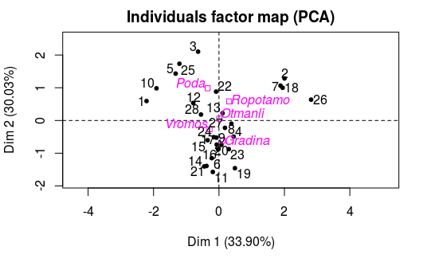

````r
```r
```r
water.zostera.all.scaled.noout <- water.zostera.all.scaled %>%
  filter(!row_number() %in% c(1, 23, 29))
water.zostera.all.scaled.noout.pca <- PCA(water.zostera.all.scaled.noout, scale.unit = FALSE, quali.sup = 1)
````

[output not shown]

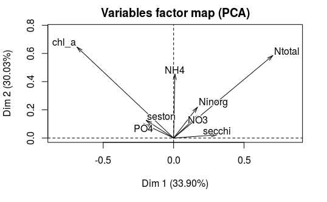

````r
```r
```r
Investigate(water.zostera.all.scaled.noout.pca,
            file = \pca_water_zostera_all_noout.Rmd\, document = \html_document\,
            out.selec = FALSE, # NB if outlier detection is performed, the function fails, and I can't see a way to fix it
            remove.temp = TRUE)
````

Great. Now I’ll try it properly - I’ll first remove the most correlated variables, because this leads to artificial inflation of the significance of representation (?).

````r
```r
```r
# calculate the correlation matrix (on the numeric variables only)
water.zostera.all.cors <- cor(water.zostera.all %>% select(-c(station:month)))

# find and eliminate the highly correlated variables. NB names = FALSE, to return column index
highly.cor.water.zostera.all <- findCorrelation(water.zostera.all.cors, cutoff = 0.85)
(water.zostera.red <- water.zostera.all %>%
    select(-c(station:month)) %>% # otherwise column indices don't match
    select(-highly.cor.water.zostera.all)
)
````

| chl_a | NH4 | NO3 | Ntotal | PO4 | seston | secchi |
| --- | --- | --- | --- | --- | --- | --- |
| 3.51650 | 0.700 | 2.0160 | 27.49000 | 2.67200 | 4.5365 | NaN |
| 6.60050 | 0.575 | 0.9660 | 13.88850 | 0.41050 | 2.8000 | 2.5 |
| 1.97250 | 1.425 | 2.8340 | 29.74800 | 0.01500 | 1.4300 | 4.0 |
| 5.79650 | 1.500 | 2.5980 | 20.49450 | 0.23150 | 2.5400 | NaN |
| 2.31050 | 0.475 | 1.1660 | 21.64500 | 0.23100 | 2.2100 | 3.0 |
| 6.60400 | 0.775 | 0.9180 | 21.47150 | 0.64150 | 1.8000 | 2.5 |
| 2.75800 | 0.300 | 1.1805 | 14.96350 | 0.23150 | 2.0000 | NaN |
| 2.73650 | 1.000 | 2.2455 | 30.22150 | 0.03000 | 1.3300 | 6.0 |
| 2.92850 | 0.525 | 1.6410 | 22.21850 | 0.16400 | 2.2100 | 3.2 |
| 3.20100 | 0.400 | 0.9180 | 19.40800 | 0.12650 | 2.0300 | 3.0 |

[output cut: 21 more lines]

```
Missing values are imputed by the mean of the variable: you should use the imputePCA function of the missMDA package
```

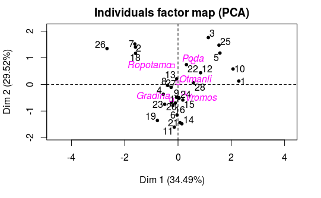

````r
```r
```r
## scale and center the reduced dataset
water.zostera.red.scaled <- scale(water.zostera.red,
                                  center = TRUE, scale = TRUE)
water.zostera.red.scaled <- bind_cols(water.zostera.all %>% select(station),
                                      as.tibble(water.zostera.red.scaled))
## filter out the three outliers
water.zostera.red.scaled <- water.zostera.red.scaled %>%
  filter(!row_number() %in% c(1, 23, 29))
water.zostera.red.pca <- PCA(water.zostera.red.scaled, scale.unit = FALSE, quali.sup = 1)
````

[output not shown]

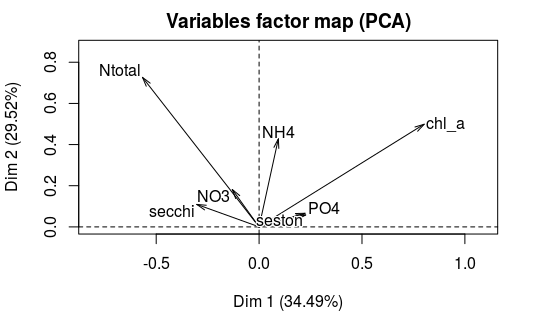

````r
```r
```r
Investigate(water.zostera.red.pca,
            file = \pca_water_zostera_red_report.Rmd\, document = \html_document\,
            out.selec = FALSE, # NB if outlier detection is performed, the function fails, and I can't see a way to fix it
            remove.temp = TRUE)
````

Save this PCA, too.

````r
```r
```r
write_rds(water.zostera.red.pca,
          here(save.dir, \pca_water_zostera_red.RDS\))
````

Now I’ll do the same as for the sand stations, and **try again with LUSI**.

````r
```r
```r
## add LUSI to the dataset
water.zostera.all.LUSI <-  inner_join(water.zostera.all,
                                      lusi %>% select(-watershed),
                                      by = \station\) %>%
  ## convert station back to factor
  mutate(station = factor(station, levels = c(\Poda\, \Otmanli\, \Vromos\, \Gradina\, \Ropotamo\))) %>%
  arrange(station)
````

```
Column `station` joining factor and character vector, coercing into character vector
```

````r
```r
```r
## calculate the correlation matrix (on the numeric variables only)
water.zostera.all.LUSI.cors <- cor(water.zostera.all.LUSI %>% select(-c(station:month)))

## find and eliminate the highly correlated variables. NB names = FALSE, to return column index
highly.cor.water.zostera.all.LUSI <- findCorrelation(water.zostera.all.LUSI.cors, cutoff = 0.85)
(water.zostera.LUSI.red <- water.zostera.all.LUSI %>%
    select(-c(station:month)) %>% # otherwise column indices don't match
    select(-highly.cor.water.zostera.all.LUSI)
)
````

| chl_a | NH4 | NO3 | Ntotal | PO4 | seston | secchi | LUSI |
| --- | --- | --- | --- | --- | --- | --- | --- |
| 3.51650 | 0.700 | 2.0160 | 27.49000 | 2.67200 | 4.5365 | NaN | 6.25 |
| 6.60050 | 0.575 | 0.9660 | 13.88850 | 0.41050 | 2.8000 | 2.5 | 6.25 |
| 1.97250 | 1.425 | 2.8340 | 29.74800 | 0.01500 | 1.4300 | 4.0 | 6.25 |
| 5.79650 | 1.500 | 2.5980 | 20.49450 | 0.23150 | 2.5400 | NaN | 6.25 |
| 2.31050 | 0.475 | 1.1660 | 21.64500 | 0.23100 | 2.2100 | 3.0 | 6.25 |
| 6.60400 | 0.775 | 0.9180 | 21.47150 | 0.64150 | 1.8000 | 2.5 | 6.25 |
| 2.75800 | 0.300 | 1.1805 | 14.96350 | 0.23150 | 2.0000 | NaN | 6.25 |
| 2.73650 | 1.000 | 2.2455 | 30.22150 | 0.03000 | 1.3300 | 6.0 | 6.25 |
| 2.92850 | 0.525 | 1.6410 | 22.21850 | 0.16400 | 2.2100 | 3.2 | 6.25 |
| 3.20100 | 0.400 | 0.9180 | 19.40800 | 0.12650 | 2.0300 | 3.0 | 6.25 |

[output cut: 21 more lines]

```
Missing values are imputed by the mean of the variable: you should use the imputePCA function of the missMDA package
```

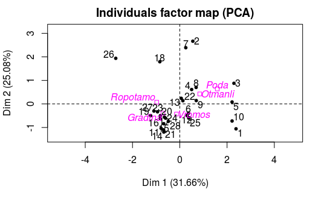

````r
```r
```r
## scale and center the reduced dataset
water.zostera.LUSI.red.scaled <- scale(water.zostera.LUSI.red,
                                       center = TRUE, scale = TRUE)
water.zostera.LUSI.red.scaled <- bind_cols(water.zostera.all.LUSI %>% select(station),
                                           as.tibble(water.zostera.LUSI.red.scaled))
## filter out - manually - the outliers
water.zostera.LUSI.red.scaled <- water.zostera.LUSI.red.scaled %>%
  filter(!row_number() %in% c(1, 23, 29))
water.zostera.LUSI.red.pca <- PCA(water.zostera.LUSI.red.scaled, scale.unit = FALSE, quali.sup = 1)
````

[output not shown]

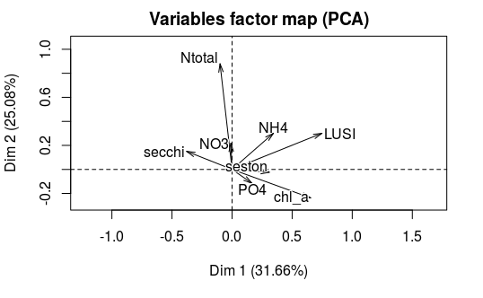

````r
```r
```r
Investigate(water.zostera.LUSI.red.pca,
            file = \pca_water_zostera_LUSI_red_report.Rmd\, document = \html_document\,
            out.selec = FALSE, # NB if outlier detection is performed, the function fails, and I can't see a way to fix it
            remove.temp = TRUE)
````

OK, at least THIS manages to separate the stations significantly. Yay!

Save this PCA, too.

````r
```r
```r
write_rds(water.zostera.LUSI.red.pca,
          here(save.dir, \pca_water_zostera_LUSI_red.RDS\))
````

All right, after much deliberation - decided to see if using the long-term data for Burgas Bay, with stations (more or less) recoded to correspond to the seagrass meadows, amounts to anything.

````r
```r
```r
## average the data over the depths
(water.zostera.LT <- water.zostera.LT %>%
   group_by(station, year, month) %>%
   summarize_all(mean) %>%
   select(-depth) %>%
   ungroup()
)
````

```r
# calculate the correlation matrix (on the numeric variables only)
water.zostera.LT.cors <- cor(water.zostera.LT %>% select(-c(station:month)))

# find and eliminate the highly correlated variables. NB names = FALSE, to return column index
highly.cor.water.zostera.LT <- findCorrelation(water.zostera.LT.cors, cutoff = 0.85)
(water.zostera.LT.red <- water.zostera.LT %>%
    select(-c(station:month)) %>% # otherwise column indices don't match
    select(-highly.cor.water.zostera.LT)
)
```

| chl_a | NH4 | NO3 | Ntotal | PO4 | seston | secchi |
| --- | --- | --- | --- | --- | --- | --- |
| 0.7163333 | 0.5833333 | 0.4590000 | 3.071333 | 0.14900000 | 1.4800000 | 3.00 |
| 0.9383333 | 0.4666667 | 0.8380000 | 13.045333 | 0.17400000 | 1.5666667 | 1.50 |
| 4.9393333 | 0.8666667 | 1.0406667 | 16.107333 | 0.24400000 | 5.4666667 | 1.50 |
| 1.1540000 | 0.3833333 | 0.6073333 | 15.767667 | 0.17400000 | 0.9866667 | 3.00 |
| 4.9703333 | 0.7333333 | 0.6773333 | 9.701333 | 0.16400000 | 1.3666667 | 2.50 |
| 1.4280000 | 0.9166667 | 0.9026667 | 16.194000 | 0.20400000 | 3.8266667 | 2.50 |
| 4.3340000 | 4.6666667 | 8.6393333 | 40.640333 | 1.48733333 | 5.9940000 | 1.20 |
| 3.3553333 | 3.9500000 | 14.5436667 | 67.140333 | 3.25866667 | 5.6000000 | 0.50 |
| 7.3680000 | 0.8166667 | 2.5583333 | 26.725667 | 0.38333333 | 2.1583333 | 2.00 |
| 2.8273333 | 0.9000000 | 7.6016667 | 17.700000 | 0.14900000 | 0.9366667 | 2.50 |

[output cut: 114 more lines]

```
Missing values are imputed by the mean of the variable: you should use the imputePCA function of the missMDA package
```

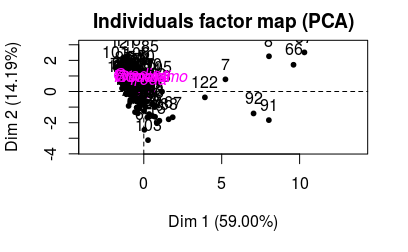

````r
```r
```r
## scale and center the reduced dataset
water.zostera.LT.red.scaled <- scale(water.zostera.LT.red,
                                     center = TRUE, scale = TRUE)
water.zostera.LT.red.scaled <- bind_cols(water.zostera.LT %>% select(station),
                                         as.tibble(water.zostera.LT.red.scaled))
water.zostera.LT.red.pca <- PCA(water.zostera.LT.red.scaled, scale.unit = FALSE, quali.sup = 1)
````

[output not shown]

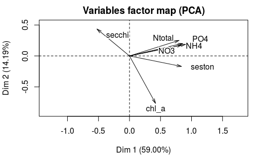

````r
```r
```r
Investigate(water.zostera.LT.red.pca,
            file = \pca_water_zostera_LT_red_report.Rmd\, document = \html_document\,
            out.selec = FALSE, # NB if outlier detection is performed, the function fails miserably, and I can't see a way to fix it
            remove.temp = TRUE)
````

Well unsurprisingly, it’s the same picture as for the sand stations (same data). And it *still* doesn’t manage to be significant enough to separate the stations on the plane..  
Whatever. Save this PCA, too.

````r
```r
```r
write_rds(water.zostera.LT.red.pca,
          here(save.dir, \pca_water_zostera_LT_red.RDS\))
````

Same for the **sediments - with all available data**.  
Import all available sediment data for the seagrass stations.

````r
```r
```r
sediments.zostera.all <- read_csv(here(save.dir, \sediments_seagrass_raw_clean.csv\))
```r
```r
## make station a factor & rearrange
(sediments.zostera.all <- sediments.zostera.all %>%
  mutate(station = factor(station, levels = c(\Poda\, \Otmanli\, \Vromos\, \Gradina\, \Ropotamo\))) %>%
    arrange(station)
)
````

| station | month | year | habitat | TOM | moisture_content | mean_grain_size | sorting | gravel | sand | silt_clay | Cu | Pb | Zn | Cd | Mn | Fe | Ni |
| --- | --- | --- | --- | --- | --- | --- | --- | --- | --- | --- | --- | --- | --- | --- | --- | --- | --- |
| Poda | 6 | 2013 | Z | 2.140068 | 27.09861 | 74.44179 | 1.339402 | 2.7198663 | 88.85319 | 8.42694737 | NA | NA | NA | NA | NA | NA | NA |
| Poda | 6 | 2013 | Z | 2.038826 | 27.09861 | 73.18942 | 1.481776 | 0.4019374 | 85.56051 | 14.03755574 | NA | NA | NA | NA | NA | NA | NA |
| Poda | 7 | 2014 | Z | 2.120016 | 26.61388 | 73.86700 | 1.431000 | 2.0543232 | 86.56654 | 11.37913265 | 17.223 | 5.712 | 27.241 | 1.230 | 194.025 | 6604.657 | 8.787 |
| Poda | 7 | 2014 | Z | 1.955580 | 24.86096 | 74.70456 | 1.210808 | 1.9589640 | 91.99100 | 6.05003164 | NA | NA | NA | NA | NA | NA | NA |
| Otmanli | 6 | 2013 | Z | 1.891948 | 28.28708 | 74.90162 | 2.128386 | 5.4144366 | 86.59910 | 7.98646686 | NA | NA | NA | NA | NA | NA | NA |
| Otmanli | 6 | 2013 | Z | 2.417606 | 33.33752 | 72.18052 | 1.524092 | 0.4999458 | 83.34277 | 16.15728734 | NA | NA | NA | NA | NA | NA | NA |
| Otmanli | 7 | 2014 | Z | 2.374579 | 24.90324 | 75.68377 | 1.821531 | 6.1420873 | 90.29371 | 3.56419993 | 24.713 | 9.341 | 893.266 | 8.746 | 467.192 | 893.983 | 12.464 |
| Otmanli | 7 | 2014 | Z | 2.434263 | 27.35319 | 76.28339 | 1.933517 | 11.4828320 | 83.08281 | 5.43435996 | NA | NA | NA | NA | NA | NA | NA |
| Vromos | 7 | 2014 | Z | 2.695494 | 25.13377 | 75.13955 | 1.119535 | 1.0357724 | 96.77527 | 2.18896219 | 420.320 | 25.647 | 532.874 | 7.314 | 634.703 | 9459.665 | 12.861 |
| Vromos | 7 | 2014 | Z | 2.773576 | 22.87866 | 74.78928 | 1.122228 | 0.8146804 | 94.75872 | 4.42660054 | NA | NA | NA | NA | NA | NA | NA |

[output cut: 6 more lines]

````r
```r
```r
## remove the heavy metals, which are still in the dataset for some reason
sediments.zostera.all.sub <- sediments.zostera.all %>%
  select(-habitat, -c(Cu:Ni))
## calculate the correlation matrix (on the numeric variables only)
sediments.zostera.all.cors <- cor(sediments.zostera.all.sub %>% select(-c(station:year)))

## find and eliminate the highly correlated variables. NB names = FALSE, to return column index
highly.cor.sediments.zostera.all.sub <- findCorrelation(sediments.zostera.all.cors, cutoff = 0.85)
(sediments.zostera.red <- sediments.zostera.all.sub %>%
    select(-c(station:year)) %>% # otherwise column indices don't match
    select(-highly.cor.sediments.zostera.all.sub)
)
````

| TOM | moisture_content | mean_grain_size | sand | silt_clay |
| --- | --- | --- | --- | --- |
| 2.140068 | 27.09861 | 74.44179 | 88.85319 | 8.42694737 |
| 2.038826 | 27.09861 | 73.18942 | 85.56051 | 14.03755574 |
| 2.120016 | 26.61388 | 73.86700 | 86.56654 | 11.37913265 |
| 1.955580 | 24.86096 | 74.70456 | 91.99100 | 6.05003164 |
| 1.891948 | 28.28708 | 74.90162 | 86.59910 | 7.98646686 |
| 2.417606 | 33.33752 | 72.18052 | 83.34277 | 16.15728734 |
| 2.374579 | 24.90324 | 75.68377 | 90.29371 | 3.56419993 |
| 2.434263 | 27.35319 | 76.28339 | 83.08281 | 5.43435996 |
| 2.695494 | 25.13377 | 75.13955 | 96.77527 | 2.18896219 |
| 2.773576 | 22.87866 | 74.78928 | 94.75872 | 4.42660054 |

[output cut: 6 more lines]

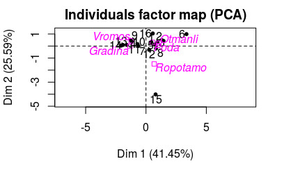

````r
```r
```r
## scale and center the reduced dataset
sediments.zostera.red.scaled <- scale(sediments.zostera.red,
                                      center = TRUE, scale = TRUE)
sediments.zostera.red.scaled <- bind_cols(sediments.zostera.all %>% select(station),
                                          as.tibble(sediments.zostera.red.scaled))
sediments.zostera.red.pca <- PCA(sediments.zostera.red.scaled, scale.unit = FALSE, quali.sup = 1)
````